# ReCell Case study v0.1 - Final-Final 082021

## Background:

Used and refurbished phone market has grown considerably over the past decade, and a new IDC (International Data Corporation) forecast predicts that the used phone market would be worth $52.7bn by 2023 with a compound annual growth rate (CAGR) of 13.6% from 2018 to 2023.

The rising potential of this comparatively under-the-radar market, **"ReCell"**, a startup aiming to tap the potential in this market. They have realized they would need a ML based solution to develop a dynamic pricing strategy for used and refurbished smartphones.

## Objective:

They have sourced data for used and refurbished cell phones and various attributes, with this data, our main objective is -

- Analyze the data and draw observations and insights
- Process the data to build a Linear Regression model
- Determine performance of the model, present a final model which will help business to predict prices

## Data Definition:

- brand_name: Name of manufacturing brand
- os: OS on which the phone runs
- screen_size: Size of the screen in cm
- 4g: Whether 4G is available or not
- 5g: Whether 5G is available or not
- main_camera_mp: Resolution of the rear camera in megapixels
- selfie_camera_mp: Resolution of the front camera in megapixels
- int_memory: Amount of internal memory (ROM) in GB
- ram: Amount of RAM in GB
- battery: Energy capacity of the phone battery in mAh
- weight: Weight of the phone in grams
- release_year: Year when the phone model was released
- days_used: Number of days the used/refurbished phone has been used
- new_price: Price of a new phone of the same model in euros
- used_price: Price of the used/refurbished phone in euros

## Importing necessary libraries

```python
# this will help in making the Python code more structured automatically (good coding practice)
%load_ext nb_black

# Libraries to help with reading and manipulating data
import numpy as np
import pandas as pd

# Libraries to help with data visualization
import matplotlib.pyplot as plt
import seaborn as sns

sns.set()
%matplotlib inline

# to split the data into train and test
from sklearn.model_selection import train_test_split

# to build linear regression_model
from sklearn.linear_model import LinearRegression

# to check model performance
from sklearn.metrics import mean_absolute_error, mean_squared_error, r2_score

# to build linear regression_model using statsmodels
import statsmodels.api as sm

pd.set_option(
    "expand_frame_repr", False
)  # To avoid data formatted in multiple lines for pandas dataframes
# Library to suppress warnings or deprecation notes
import warnings

warnings.filterwarnings("ignore")
```

## Data Overview

### Loading the data

```python
dfused_bkup = pd.read_csv("used_phone_data.csv")
# Also making a working copy of the data to avoid updating the original dataset
dfused = dfused_bkup.copy()
```

### Let's check if the data has been loaded properly

```python
dfused.head()  # Checking head of the data
```

|  | brand_name | os | screen_size | 4g | 5g | main_camera_mp | selfie_camera_mp | int_memory | ram | battery | weight | release_year | days_used | new_price | used_price |
| --- | --- | --- | --- | --- | --- | --- | --- | --- | --- | --- | --- | --- | --- | --- | --- |
| 0 | Honor | Android | 23.97 | yes | no | 13.0 | 5.0 | 64.0 | 3.0 | 3020.0 | 146.0 | 2020 | 127 | 111.62 | 86.96 |
| 1 | Honor | Android | 28.10 | yes | yes | 13.0 | 16.0 | 128.0 | 8.0 | 4300.0 | 213.0 | 2020 | 325 | 249.39 | 161.49 |
| 2 | Honor | Android | 24.29 | yes | yes | 13.0 | 8.0 | 128.0 | 8.0 | 4200.0 | 213.0 | 2020 | 162 | 359.47 | 268.55 |
| 3 | Honor | Android | 26.04 | yes | yes | 13.0 | 8.0 | 64.0 | 6.0 | 7250.0 | 480.0 | 2020 | 345 | 278.93 | 180.23 |
| 4 | Honor | Android | 15.72 | yes | no | 13.0 | 8.0 | 64.0 | 3.0 | 5000.0 | 185.0 | 2020 | 293 | 140.87 | 103.80 |

```python
dfused.tail()  # Checking tail of the data
```

|  | brand_name | os | screen_size | 4g | 5g | main_camera_mp | selfie_camera_mp | int_memory | ram | battery | weight | release_year | days_used | new_price | used_price |
| --- | --- | --- | --- | --- | --- | --- | --- | --- | --- | --- | --- | --- | --- | --- | --- |
| 3566 | Asus | Android | 15.88 | yes | no | NaN | 8.0 | 64.0 | 6.0 | 5000.0 | 190.0 | 2019 | 232 | 654.5000 | 490.96 |
| 3567 | Asus | Android | 15.24 | yes | no | 13.0 | 8.0 | 128.0 | 8.0 | 4000.0 | 200.0 | 2018 | 541 | 518.8145 | 259.30 |
| 3568 | Alcatel | Android | 18.73 | yes | no | 13.0 | 5.0 | 32.0 | 3.0 | 4000.0 | 165.0 | 2020 | 201 | 92.6500 | 69.81 |
| 3569 | Alcatel | Android | 18.73 | yes | no | 13.0 | 5.0 | 32.0 | 2.0 | 4000.0 | 160.0 | 2020 | 149 | 101.9150 | 76.07 |
| 3570 | Alcatel | Android | 13.49 | yes | no | 13.0 | 5.0 | 16.0 | 2.0 | 4000.0 | 168.0 | 2020 | 176 | 72.2415 | 50.48 |

### Shape of the data

```python
dfused.shape  # gives the shape of the data
```

```
(3571, 15)
```

#### Observations:

- Data got loaded properly, and head, tail of the data looks consistent with the data definition
- From the shape of the data we can see, we have 3571 observations with 15 different attributes

### Let's view the info of the data how it's loaded

```python
dfused.info()  # info of the dataset including data types and non null observation numbers per column
```

```
<class 'pandas.core.frame.DataFrame'>
RangeIndex: 3571 entries, 0 to 3570
Data columns (total 15 columns):
 #   Column            Non-Null Count  Dtype
---  ------            --------------  -----
 0   brand_name        3571 non-null   object
 1   os                3571 non-null   object
 2   screen_size       3571 non-null   float64
 3   4g                3571 non-null   object
 4   5g                3571 non-null   object
 5   main_camera_mp    3391 non-null   float64
 6   selfie_camera_mp  3569 non-null   float64
 7   int_memory        3561 non-null   float64
 8   ram               3561 non-null   float64
 9   battery           3565 non-null   float64
 10  weight            3564 non-null   float64
 11  release_year      3571 non-null   int64
 12  days_used         3571 non-null   int64
 13  new_price         3571 non-null   float64
 14  used_price        3571 non-null   float64
dtypes: float64(9), int64(2), object(4)
memory usage: 418.6+ KB
```

#### Observations:

- brand name, os, 4g, 5g columns are loaded as object, which is as per expectation.
- There are 11 numerical columns
- Except release year and days used which are integer all other numerical columns loaded as float, this is also as per epectation, which means there are no text type/special characters in these columns.
- We can see there are less non null values in some columns such as main camera mp, selfie camera mp etc. We will take further look at those.

### Let's identify the columns having missing values and how many observations are missing in each of them

```python
dfused.isnull().sum()  # gives total number of null values for each column
```

```
brand_name            0
os                    0
screen_size           0
4g                    0
5g                    0
main_camera_mp      180
selfie_camera_mp      2
int_memory           10
ram                  10
battery               6
weight                7
release_year          0
days_used             0
new_price             0
used_price            0
dtype: int64
```

#### Observations:

- There are total 6 columns having missing values
- main_camera_mp having the highest number of missing values

### Let's check if the data has any duplicate values in it

```python
dfused.duplicated().sum()
```

```
0
```

- We can see there are no duplicate values present in the data

### Let's have a quick look at the data summary

```python
# Let's look at the statistical summary of the data
pd.set_option(
    "display.float_format", lambda x: "%.3f" % x
)  # to display numbers rounded off to 3 decimal places

dfused.describe(include="all").T
```

|  | count | unique | top | freq | mean | std | min | 25% | 50% | 75% | max |
| --- | --- | --- | --- | --- | --- | --- | --- | --- | --- | --- | --- |
| brand_name | 3571 | 34 | Others | 509 | NaN | NaN | NaN | NaN | NaN | NaN | NaN |
| os | 3571 | 4 | Android | 3246 | NaN | NaN | NaN | NaN | NaN | NaN | NaN |
| screen_size | 3571.000 | NaN | NaN | NaN | 14.804 | 5.153 | 2.700 | 12.700 | 13.490 | 16.510 | 46.360 |
| 4g | 3571 | 2 | yes | 2359 | NaN | NaN | NaN | NaN | NaN | NaN | NaN |
| 5g | 3571 | 2 | no | 3419 | NaN | NaN | NaN | NaN | NaN | NaN | NaN |
| main_camera_mp | 3391.000 | NaN | NaN | NaN | 9.400 | 4.818 | 0.080 | 5.000 | 8.000 | 13.000 | 48.000 |
| selfie_camera_mp | 3569.000 | NaN | NaN | NaN | 6.547 | 6.879 | 0.300 | 2.000 | 5.000 | 8.000 | 32.000 |
| int_memory | 3561.000 | NaN | NaN | NaN | 54.533 | 84.696 | 0.005 | 16.000 | 32.000 | 64.000 | 1024.000 |
| ram | 3561.000 | NaN | NaN | NaN | 4.057 | 1.392 | 0.030 | 4.000 | 4.000 | 4.000 | 16.000 |
| battery | 3565.000 | NaN | NaN | NaN | 3067.226 | 1364.207 | 80.000 | 2100.000 | 3000.000 | 4000.000 | 12000.000 |
| weight | 3564.000 | NaN | NaN | NaN | 179.424 | 90.281 | 23.000 | 140.000 | 159.000 | 184.000 | 950.000 |
| release_year | 3571.000 | NaN | NaN | NaN | 2015.965 | 2.292 | 2013.000 | 2014.000 | 2016.000 | 2018.000 | 2020.000 |
| days_used | 3571.000 | NaN | NaN | NaN | 675.391 | 248.641 | 91.000 | 536.000 | 690.000 | 872.000 | 1094.000 |
| new_price | 3571.000 | NaN | NaN | NaN | 237.389 | 197.546 | 9.130 | 120.130 | 189.800 | 291.935 | 2560.200 |
| used_price | 3571.000 | NaN | NaN | NaN | 109.880 | 121.501 | 2.510 | 45.205 | 75.530 | 126.000 | 1916.540 |

#### Observations:

- Total 34 unique values in phone brands, highest observations are from phones which are classified as others
- Android phones are predominant
- Phones are having ram as high as 16, as low as .03, however majority of phones are having 4gb ram, as 25%,50% and 75% shows as 4GB
- Battery range is from 80mAh to 12000mAh
- Phones are release from 2013 to 2020
- Phones new price and used proce has value as low as ~9 and ~2 euros

## Exploratory Data Analysis

### Let's check the categorical columns and their unique values proportions

#### Below function will help annotate the bar plots

```python
# This function will take the plot and feature as input and calculate percentages for each category, followed by
# annotating them in the plot
def perc_annot(plot, feature):
    tot = len(feature)
    for p in ax.patches:
        percentage = "{:.1f}%".format(
            100 * p.get_height() / tot
        )  # percentage of each class of the category
        x = p.get_x() + p.get_width() / 2 - 0.10  # width of the plot
        y = p.get_y() + p.get_height() + 30  # hieght of the plot
        ax.annotate(percentage, (x, y), size=12)  # annotate the percantage
```

### Visualizing the categorical columns

- We will visualize the brand separately as we expect there will be large number of unique brands available

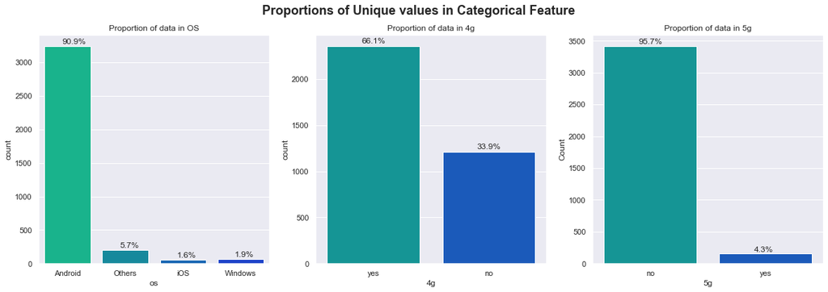

```python
fig, (ax1, ax2, ax3) = plt.subplots(
    1, 3, figsize=(20, 6)
)  # Create 2 rows and 2 column wise subplots

ax = sns.countplot(dfused["os"], palette="winter_r", ax=ax1)  # plotting second subplot
ax.set_title("Proportion of data in OS")
plt.ylabel("Count")
perc_annot(ax1, dfused["os"])
ax = sns.countplot(dfused["4g"], palette="winter_r", ax=ax2)  # plotting third subplot
ax.set_title("Proportion of data in 4g")
plt.ylabel("Count")
perc_annot(ax2, dfused["4g"])
ax = sns.countplot(dfused["5g"], palette="winter_r", ax=ax3)  # plotting fourth subplot
ax.set_title("Proportion of data in 5g")
plt.ylabel("Count")
perc_annot(ax3, dfused["5g"])
plt.suptitle(
    "Proportions of Unique values in Categorical Feature",
    fontsize=18,
    fontweight="bold",
)
plt.show()
```

#### Observations:

- Android os phones are predominant in the dataset, close to ~91%, with second highest proportion for phones having os other than android, ios and windows
- ios and windows os phones have the lowest proportions.
- Majority ~66% phones have 4g
- Majority ~96% phones doesn't have 5g

#### Visualizing the brand column

```python
ub = len(dfused["brand_name"].value_counts())  # find the total number of unique values
ub
```

```
34
```

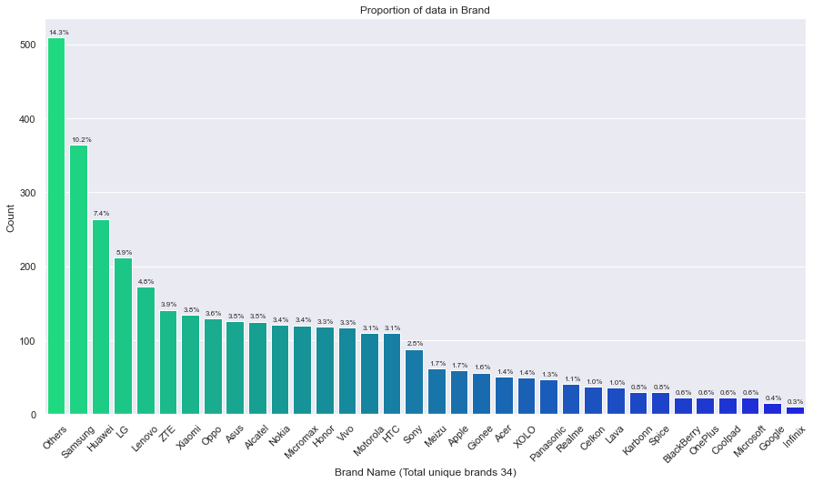

```python
fig, ax = plt.subplots(figsize=(15, 8))
ax = sns.countplot(
    dfused["brand_name"],
    palette="winter_r",
    ax=ax,
    order=dfused["brand_name"].value_counts().index,
)  # plotting first subplot
ax.set_title("Proportion of data in Brand")
ax.set_xticklabels(ax.get_xticklabels(), rotation=45)
plt.xlabel(f"Brand Name (Total unique brands {ub})")
plt.ylabel("Count")
# perc_annot(ax1,dfused['brand_name']) #perc_annot() function is used to show the percentages annotation
tot = len(dfused["brand_name"])
for p in ax.patches:
    percentage = "{:.1f}%".format(
        100 * p.get_height() / tot
    )  # percentage of each class of the category
    x = p.get_x() + p.get_width() / 10  # width of the plot
    y = p.get_y() + p.get_height() + 5  # hieght of the plot
    ax.annotate(percentage, (x, y), size=8)  # annotate the percantage
```

#### Observations:

- There are total 33 unique named brands phones are present in dataset, and all other phones are grouped as 'others' in dataset
- Samsung has highest proportions ~ 10.2% among named brands, and 14.3% phones belongs to phones for which brand names are not identified
- Infinix is the least popular brand

### Let's now visualize the distribution of all numerical columns

#### Below function will plot boxplot and histogram for any numerical columns passed

```python
# Below is a function which will take input as numerical attributes,
# titlevar to be able to dynamically populate the title for each plot
# figure size (to have the flexibility to have custom figsize if necessary), bins(for histogram) and
# returns boxplot and histogram plot for the numerical attribute passed.
def box_hist(feature, titlevar, figsize=(15, 10), bins=None):
    sns.set(style="ticks")
    sns.set_style("darkgrid")
    fig, (axb, axh) = plt.subplots(
        nrows=2,  # Number of rows to be plotted for subplot
        sharex=True,  # x-axis will be shared for all subplots
        gridspec_kw={
            "height_ratios": (0.25, 0.75)
        },  # pass on the grid spaces to Gridspace constructor for subplots
        figsize=figsize,
    )
    sns.boxplot(
        feature,
        ax=axb,
        showmeans=True,
        color="#00FFA0",
        meanprops={"markerfacecolor": "white", "markeredgecolor": "black"},
    )  # plots the boxplot and show a marker for mean value
    axb.set_title("BoxPlot for: {}".format(titlevar), fontweight="bold", fontsize=18)
    sns.distplot(
        feature, ax=axh, kde=True, bins=bins, color="#004DFD"
    ) if bins else sns.distplot(
        feature, ax=axh, kde=True, color="#004DFD"
    )  # plots histogram
    axh.axvline(
        np.mean(feature), linestyle="-", color="red"
    )  # Add a red vertical line for mean value of the feature
    axh.axvline(
        np.median(feature), linestyle="--", color="black"
    )  # Add a green vertical line for median value of the feature
    plt.ylabel("Count")
    axh.set_title(
        "Distribution Plot for: {}".format(titlevar), fontweight="bold", fontsize=18
    )
```

#### Visualizing distribution for screen size

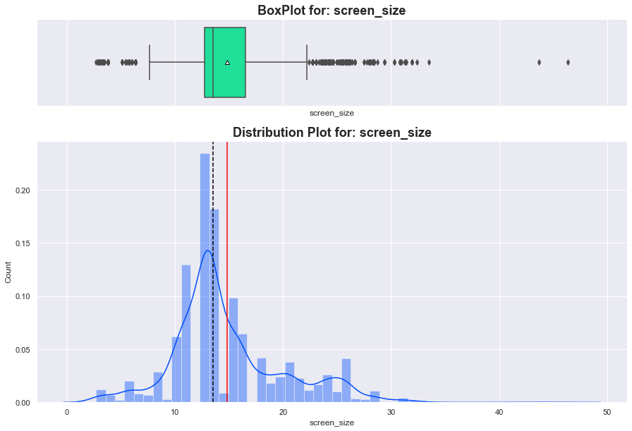

```python
box_hist(dfused["screen_size"], "screen_size")
```

#### Observations:

- Screen size of phones are ranging from ~4 to 50 cm
- Mean is greater than median, data is right skewed
- We can observe outliers on both sides of the data

### Visualizing distribution for main camera mp

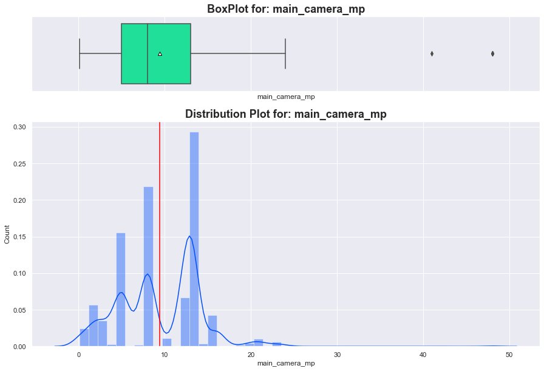

```python
box_hist(dfused["main_camera_mp"], "main_camera_mp")
```

#### Observations:

- Data is raning from 0 to 50 MP, with outliers to the right
- Data looks right skewed with mean is close to ~10.
- We have to revisit after we handle the missing values and outliers

### Visualizing distribution for selfie camera mp

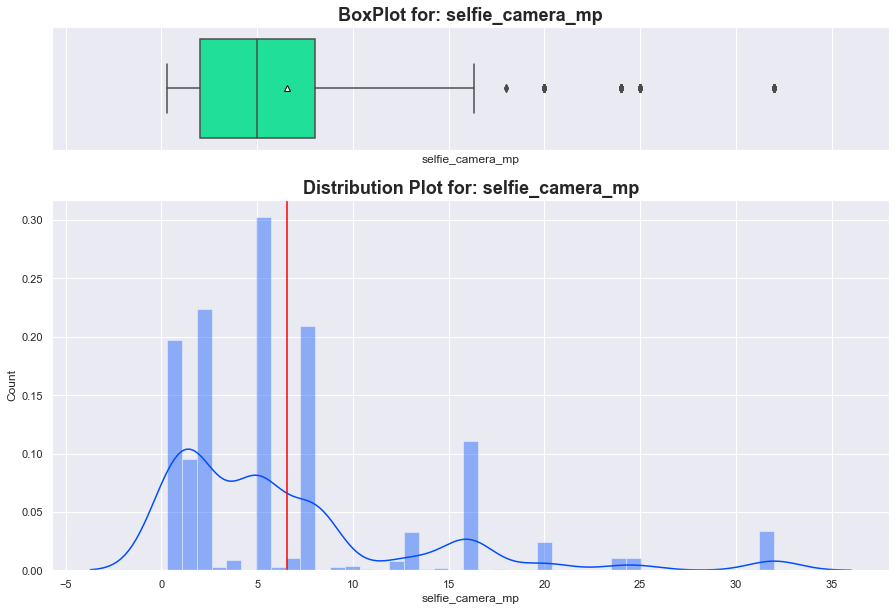

```python
box_hist(dfused["selfie_camera_mp"], "selfie_camera_mp")
```

#### Observations:

- Majority of phones selfie camera has less than ~10mp but shows phones with as high as ~35mp selfie camera
- We can observe outliers to the right, will observe after treating outliers how the data looks

### Visualizing internal memory(ROM)

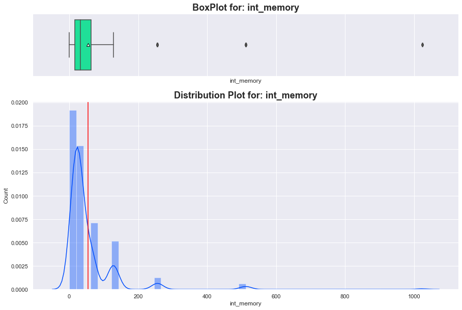

```python
box_hist(dfused["int_memory"], "int_memory")
```

### Visualizing RAM of the phones

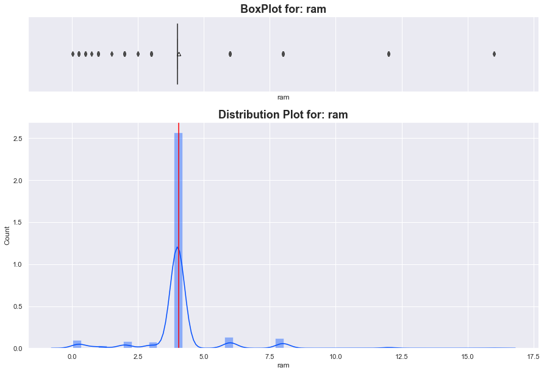

```python
box_hist(dfused["ram"], "ram")
```

#### Observations:

- Most phones have ram as 4GB, however we can observe there are very few other values on both sides, which appears as outliers
- This variable is discreet, we will not do outlier treatment on it

### Visualizing the battery data

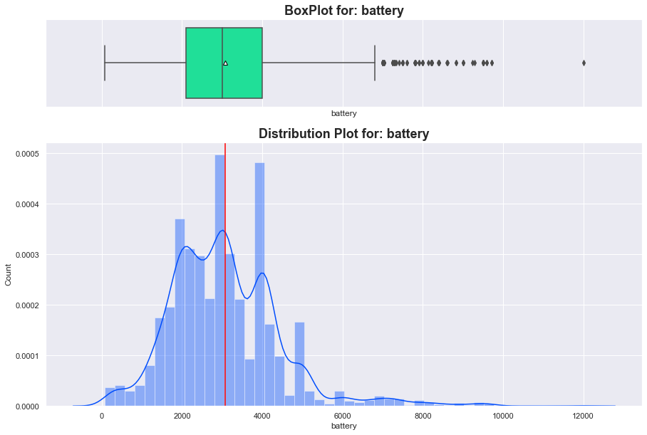

```python
box_hist(dfused["battery"], "battery")
```

#### Observations:

- Two most common battery sizes are ~3000 mAh or ~4000mAh
- There are outliers to the right

### Visualizing the weight of the phones

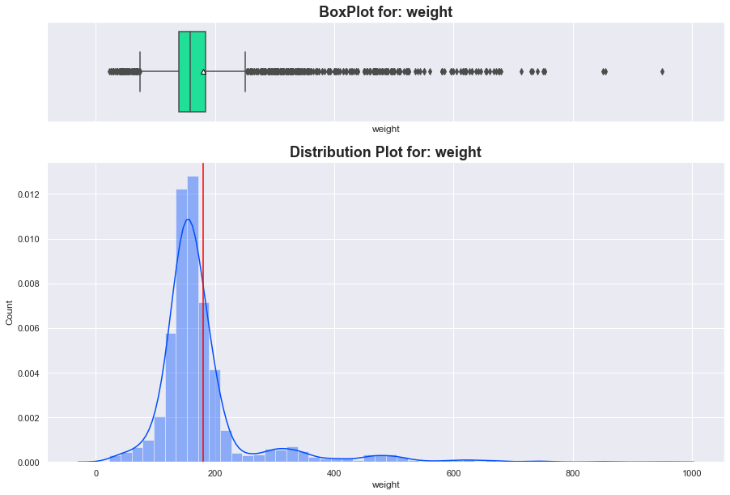

```python
box_hist(dfused["weight"], "weight")
```

#### Observations:

- Majority of the phones weigh below 200 grams
- Looks like we have lot of outliers in both sides

### Visualizing release years of the phones

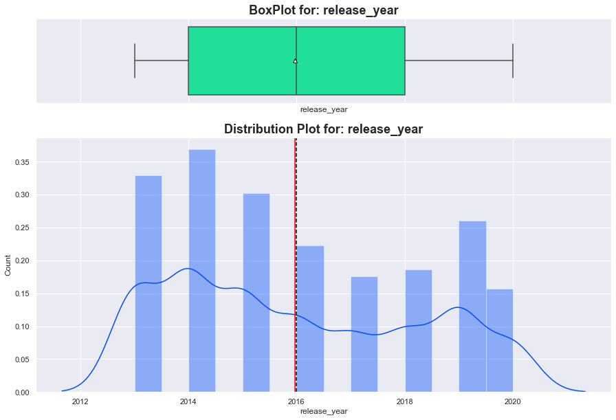

```python
box_hist(dfused["release_year"], "release_year")
```

#### Observations:

- No outliers present in the data
- Phones are ranging from released on 2013 to 2020

### Visualizing days used

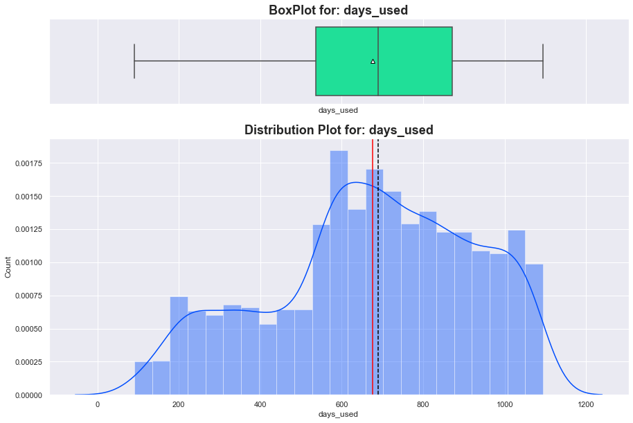

```python
box_hist(dfused["days_used"], "days_used")
```

#### Observations:

- Majority of phones are used > ~500 days
- No outliers are observed, but data looks left skewed with days used as low as ~100 days

### Visualizing new price of the phone

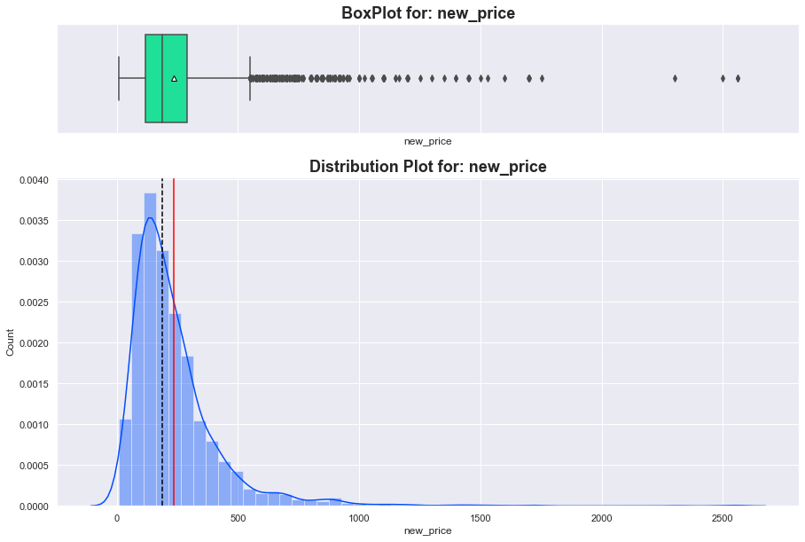

```python
box_hist(dfused["new_price"], "new_price")
```

#### Observations:

- Data is heavily right skewed and we can see lot of outliers
- Average new prices of phones are around ~250 euros

### Visualizing the used price

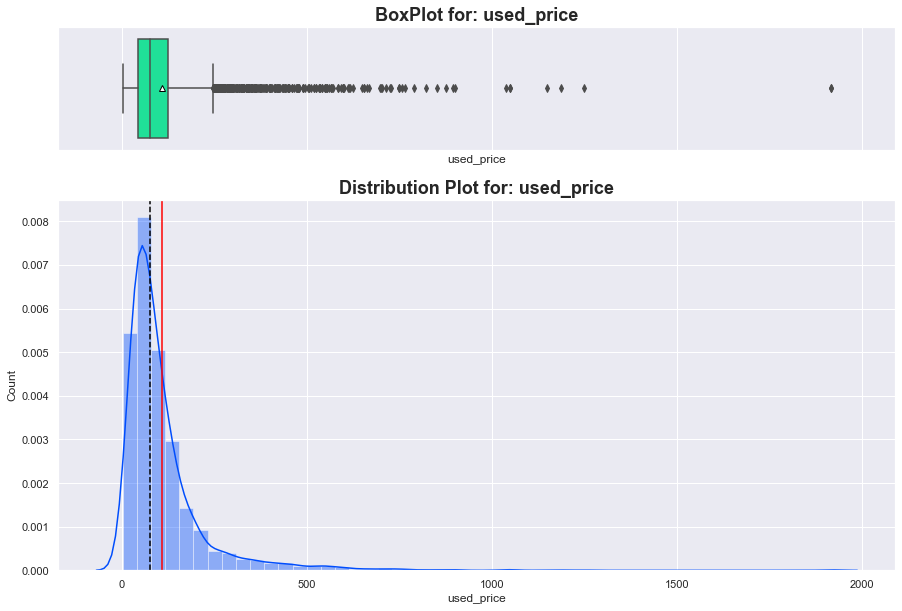

```python
box_hist(dfused["used_price"], "used_price")
```

#### Observations:

- Again the data of used price is also heavily right skewed, with lot of outliers
- Average used price of phones are around ~100-125 euros

### Let's explore how the amount of RAM vary with Brand

```python
# Creating a frame where Brand name is index and average ram as a column sorted in descending order, this
# will help in visualization order as well.
rambybrand = (
    dfused.groupby(by=["brand_name"], as_index=True)
    .mean()
    .sort_values("ram", ascending=False)["ram"]
    .to_frame("ram")
)
rambybrand
```

| brand_name | ram |
| --- | --- |
| OnePlus | 6.364 |
| Oppo | 4.961 |
| Vivo | 4.756 |
| Huawei | 4.641 |
| Honor | 4.593 |
| Xiaomi | 4.567 |
| Google | 4.533 |
| Meizu | 4.452 |
| Realme | 4.195 |
| Samsung | 4.159 |
| Sony | 4.068 |
| Asus | 4.048 |
| ZTE | 4.023 |
| HTC | 4.000 |
| Panasonic | 4.000 |
| Apple | 4.000 |
| XOLO | 4.000 |
| Microsoft | 4.000 |
| Coolpad | 3.955 |
| Motorola | 3.945 |
| Gionee | 3.933 |
| Acer | 3.902 |
| LG | 3.894 |
| Lenovo | 3.887 |
| BlackBerry | 3.830 |
| Others | 3.751 |
| Micromax | 3.750 |
| Spice | 3.750 |
| Nokia | 3.601 |
| Alcatel | 3.426 |
| Karbonn | 3.375 |
| Lava | 3.278 |
| Infinix | 2.600 |
| Celkon | 1.466 |

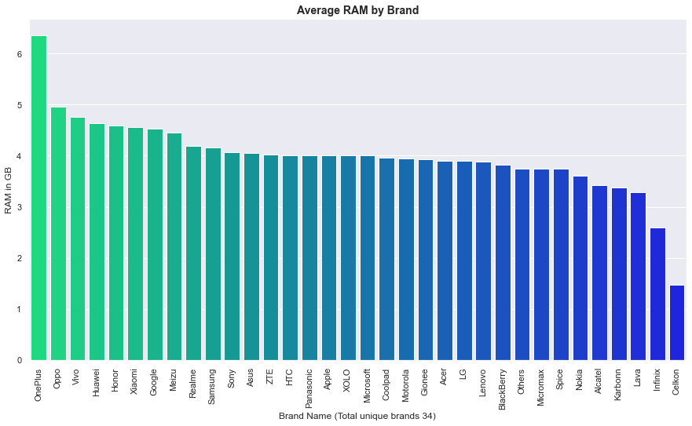

```python
fig, ax = plt.subplots(figsize=(15, 8))
ax = sns.barplot(
    dfused["brand_name"],
    dfused["ram"],
    palette="winter_r",
    ax=ax,
    ci=0,
    estimator=np.mean,
    order=rambybrand.index,
)  # plotting first subplot
ax.set_title("Average RAM by Brand", fontweight="bold", fontsize=14)
ax.set_xticklabels(ax.get_xticklabels(), rotation=90)
plt.xlabel(f"Brand Name (Total unique brands {ub})")
plt.ylabel("RAM in GB")
plt.show()
```

#### Observations:

- Majority of brands have on average 4GB of ram in their phones. This is inline with our previous observations of majority phones having 4GB of ram
- OnePlus has little over ~6GB of ram on average on their phones
- Celkon has the lowest average ram ~1.5GB on average.

### Let's explore how the weight vary for phones with larger battery (>4500mAh)

```python
largebattery = dfused[dfused["battery"] > 4500]
largebattery
```

|  | brand_name | os | screen_size | 4g | 5g | main_camera_mp | selfie_camera_mp | int_memory | ram | battery | weight | release_year | days_used | new_price | used_price |
| --- | --- | --- | --- | --- | --- | --- | --- | --- | --- | --- | --- | --- | --- | --- | --- |
| 3 | Honor | Android | 26.040 | yes | yes | 13.000 | 8.000 | 64.000 | 6.000 | 7250.000 | 480.000 | 2020 | 345 | 278.930 | 180.230 |
| 4 | Honor | Android | 15.720 | yes | no | 13.000 | 8.000 | 64.000 | 3.000 | 5000.000 | 185.000 | 2020 | 293 | 140.870 | 103.800 |
| 11 | Honor | Android | 15.720 | yes | no | 13.000 | 8.000 | 64.000 | 4.000 | 5000.000 | 185.000 | 2020 | 344 | 117.940 | 74.600 |
| 20 | Honor | Android | 25.560 | yes | no | 5.000 | 2.000 | 32.000 | 3.000 | 5100.000 | 173.000 | 2019 | 266 | 248.900 | 167.630 |
| 21 | Honor | Android | 20.320 | yes | no | 8.000 | 8.000 | 32.000 | 3.000 | 5100.000 | 173.000 | 2019 | 321 | 201.140 | 131.890 |
| ... | ... | ... | ... | ... | ... | ... | ... | ... | ... | ... | ... | ... | ... | ... | ... |
| 3536 | Samsung | Android | 16.670 | yes | yes | 8.000 | 13.000 | 128.000 | 12.000 | 5000.000 | 222.000 | 2020 | 197 | 890.800 | 667.920 |
| 3537 | Samsung | Android | 16.670 | yes | no | 8.000 | 13.000 | 128.000 | 12.000 | 5000.000 | 220.000 | 2020 | 176 | 1054.450 | 789.540 |
| 3550 | Samsung | Android | 15.880 | yes | no | 12.000 | 16.000 | 64.000 | 4.000 | 6000.000 | 188.000 | 2019 | 455 | 165.665 | 82.790 |
| 3565 | Asus | Android | 24.610 | yes | no | NaN | 24.000 | 128.000 | 8.000 | 6000.000 | 240.000 | 2019 | 325 | 1163.650 | 756.990 |
| 3566 | Asus | Android | 15.880 | yes | no | NaN | 8.000 | 64.000 | 6.000 | 5000.000 | 190.000 | 2019 | 232 | 654.500 | 490.960 |

346 rows × 15 columns

```python
# calculating the percentage of larger battery phones
large_bat_perc = len(largebattery["battery"]) / len(dfused["battery"]) * 100
print(
    f"There are {np.round(large_bat_perc,1)}% of phones having larger battery(>4500mAh)"
)
```

```
There are 9.7% of phones having larger battery(>4500mAh)
```

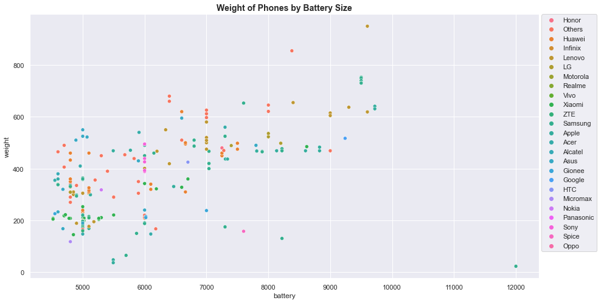

```python
# Plot a scatter plot to check the how the weight varies by the battery size
fig, ax = plt.subplots(figsize=(15, 8))
ax = sns.scatterplot(x="battery", y="weight", data=largebattery, hue="brand_name")
ax.set_title("Weight of Phones by Battery Size", fontweight="bold", fontsize=14)
plt.legend(bbox_to_anchor=(1.005, 1), loc=2, borderaxespad=0.0)
plt.show()
```

### Let's check how many phones have larger screens (> 6 inch) across brands

- As we know that the screen sizes are given in cm, let's convert it to inches before we explore this

```python
cmtoinch = lambda x: x / 2.54
dfused["screen_size_in"] = dfused["screen_size"].apply(cmtoinch)
dfused.head()
```

|  | brand_name | os | screen_size | 4g | 5g | main_camera_mp | selfie_camera_mp | int_memory | ram | battery | weight | release_year | days_used | new_price | used_price | screen_size_in |
| --- | --- | --- | --- | --- | --- | --- | --- | --- | --- | --- | --- | --- | --- | --- | --- | --- |
| 0 | Honor | Android | 23.970 | yes | no | 13.000 | 5.000 | 64.000 | 3.000 | 3020.000 | 146.000 | 2020 | 127 | 111.620 | 86.960 | 9.437 |
| 1 | Honor | Android | 28.100 | yes | yes | 13.000 | 16.000 | 128.000 | 8.000 | 4300.000 | 213.000 | 2020 | 325 | 249.390 | 161.490 | 11.063 |
| 2 | Honor | Android | 24.290 | yes | yes | 13.000 | 8.000 | 128.000 | 8.000 | 4200.000 | 213.000 | 2020 | 162 | 359.470 | 268.550 | 9.563 |
| 3 | Honor | Android | 26.040 | yes | yes | 13.000 | 8.000 | 64.000 | 6.000 | 7250.000 | 480.000 | 2020 | 345 | 278.930 | 180.230 | 10.252 |
| 4 | Honor | Android | 15.720 | yes | no | 13.000 | 8.000 | 64.000 | 3.000 | 5000.000 | 185.000 | 2020 | 293 | 140.870 | 103.800 | 6.189 |

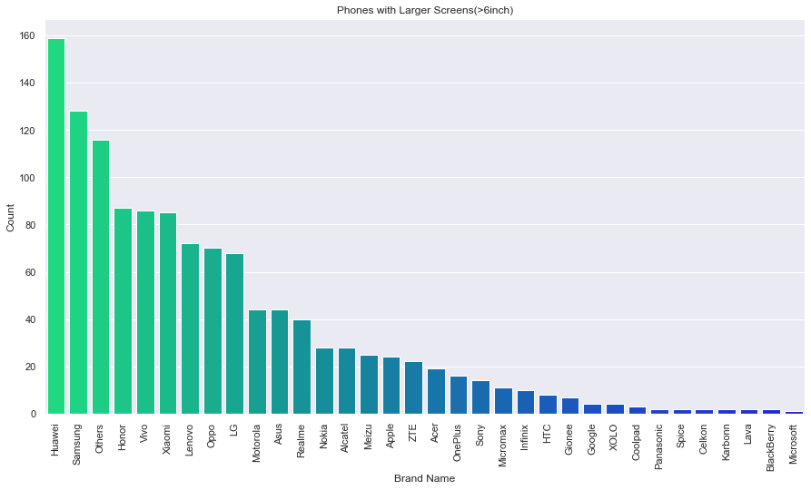

```python
fig, ax = plt.subplots(figsize=(15, 8))
ax = sns.countplot(
    dfused[dfused["screen_size_in"] > 6]["brand_name"],
    palette="winter_r",
    ax=ax,
    order=dfused[dfused["screen_size_in"] > 6]["brand_name"].value_counts().index,
)  # plotting first subplot
ax.set_title("Phones with Larger Screens(>6inch)")
ax.set_xticklabels(ax.get_xticklabels(), rotation=90)
plt.xlabel(f"Brand Name")
plt.ylabel("Count")
plt.show()
```

#### Observations:

- Huawei has the maximum number of phones which are having screens > 6 inch
- Samsung is the second highest amongst the larger screen phones
- Microsoft has the lowest number of phones with screen size > 6 inch

### Let's explore the distribution of budget phones offering >8MP selfie camera

- In order to explore this, let's first create a feature which will classify the observations in three category as budget, midrange and highend phones, this will help us explore the distribution on each category

```python
# New feature phone_type will be added through the below code and all phones whose price is below mean will be
# considered as budget phones.
dfused["phone_type"] = np.where(
    (dfused["new_price"] < dfused["new_price"].mean()), "budget", "default"
)
```

```python
# Below code will update the phone_type feature with midrange for the phones whose prices are equal or greater
# than mean and less than or equal 500(decided based on the distribution observed earlier)
dfused["phone_type"] = np.where(
    (
        (dfused["new_price"] >= dfused["new_price"].mean())
        & (dfused["new_price"] <= 500)
        & (dfused["phone_type"] != "budget")
    ),
    "midrange",
    dfused["phone_type"],
)
```

```python
# Below code will update phone_type as highend for phones with price greater than 500
dfused["phone_type"] = np.where(
    (dfused["new_price"] > 500), "highend", dfused["phone_type"]
)
```

```python
dfused["phone_type"].value_counts()
```

```
budget      2234
midrange    1091
highend      246
Name: phone_type, dtype: int64
```

```python
#finding total number of unique brands for budget phones with selfie camera > 8MP
budget_brands_cnt=len(
        set(
            dfused[
                (dfused["phone_type"] == "budget") & (dfused["selfie_camera_mp"] > 8)
            ]["brand_name"]
        )
    )
```

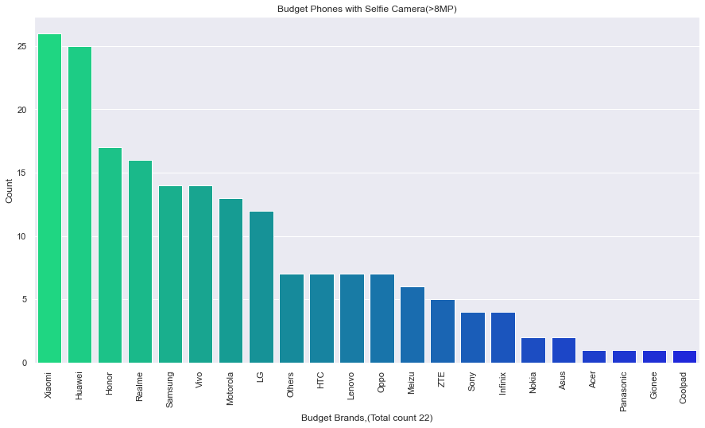

```python
# Plotting countplot to visualize the unique brands available under budget phones who offer >8MP selfie camera
fig, ax = plt.subplots(figsize=(15, 8))
ax = sns.countplot(
    dfused[(dfused["phone_type"] == "budget") & (dfused["selfie_camera_mp"] > 8)][
        "brand_name"
    ],
    palette="winter_r",
    ax=ax,
    order=dfused[(dfused["phone_type"] == "budget") & (dfused["selfie_camera_mp"] > 8)][
        "brand_name"
    ]
    .value_counts()
    .index,
)
ax.set_title("Budget Phones with Selfie Camera(>8MP)")
ax.set_xticklabels(ax.get_xticklabels(), rotation=90)
plt.xlabel(f"Budget Brands,(Total count {budget_brands_cnt})")
plt.ylabel("Count")
plt.show()
```

#### Observations:

- There are total 22 brands (21 named, and 1 as others) who are offering budget phones with selfie camera >8MP
- Xiomi & Huawei leading in offering budget phones having selfie camera > 8MP
- Acer, Gionee, Coolpad, Panasonic they are offering the least number of budget phones which has selfie camera > 8MP

### Let's explore which brand has the highest average used price

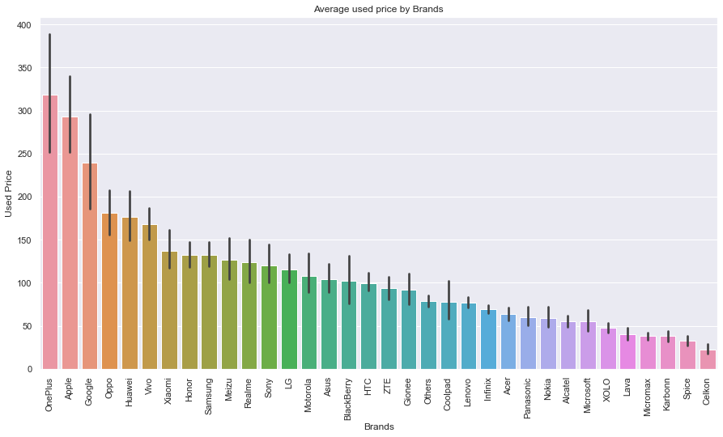

```python
fig, ax = plt.subplots(figsize=(15, 8))
sns.barplot(
    dfused["brand_name"],
    dfused["used_price"],
    order=dfused.groupby("brand_name")["used_price"]
    .mean()
    .sort_values(ascending=False)
    .index,
)
ax.set_title("Average used price by Brands")
ax.set_xticklabels(ax.get_xticklabels(), rotation=90)
plt.xlabel(f"Brands")
plt.ylabel("Used Price")
plt.show()
```

#### Observations:

- OnePlus, Apple, Google are having the highest average used_price in market.
- Celkon has the lowest average price for used phones

### Let's visualize the correlation between the numeric columns

- We will quickly check the correlation of the data in numeric columns, thought as we observed earlier there are missing values in some numeric columns, we will revisit the correlation check once we treat the missing values

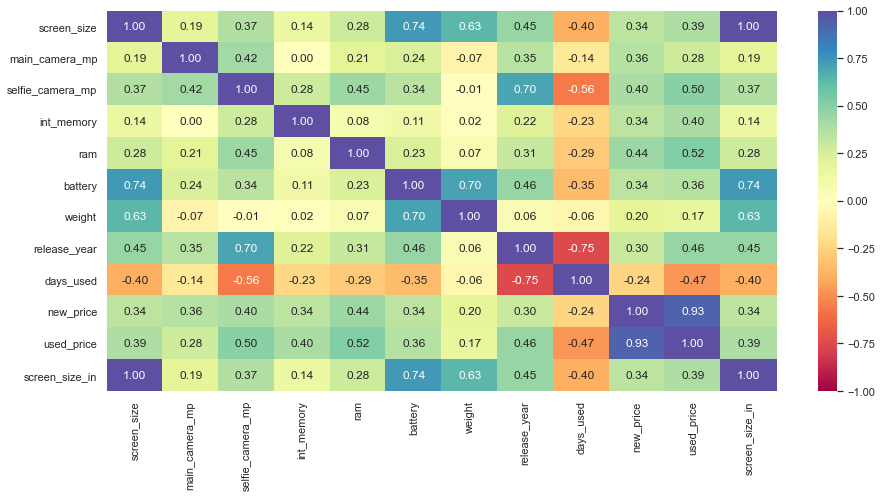

```python
# correlation heatmap
plt.figure(figsize=(15, 7))
sns.heatmap(
    dfused.corr(), annot=True, vmin=-1, vmax=1, fmt=".2f", cmap="Spectral",
)
plt.show()
```

#### Observations:

- Used price is very highly correlated with the new price, which means the higher the new price of a phone the higher the price will be for used.
- Used Price shows negative correlation with days used, which is as per our intution.
- Selfie camera, ram, release year shows positive correlation on used phone price.

## Data Preprocessing:

- Till now we just explored the data as given, and introduced a feature phone_type to answer one of the key question on given data. Let's now preprocess the data as we have observed missing values earlier.

### Missing Value treatment

```python
# let's check the columns which has missing values
dfused.isnull().sum()
```

```
brand_name            0
os                    0
screen_size           0
4g                    0
5g                    0
main_camera_mp      180
selfie_camera_mp      2
int_memory           10
ram                  10
battery               6
weight                7
release_year          0
days_used             0
new_price             0
used_price            0
screen_size_in        0
phone_type            0
dtype: int64
```

#### Observations:

- Main camera, selfie camera, internal memory, ram, battery, weight all these 6 columns has missing values. We have observed all of the columns except ram is highly skweded, we have decided to go with fill these missing values with median of respective column

```python
# list of columns with missing values
col_missing = [
    "main_camera_mp",
    "selfie_camera_mp",
    "int_memory",
    "ram",
    "battery",
    "weight",
]
medianFiller = lambda x: x.fillna(x.median())  # function to fill null with median value
dfused[col_missing] = dfused[col_missing].apply(
    medianFiller, axis=0
)  # applying the median to the missing columns and updating the rows have missing values
```

```python
dfused.isnull().sum()
```

```
brand_name          0
os                  0
screen_size         0
4g                  0
5g                  0
main_camera_mp      0
selfie_camera_mp    0
int_memory          0
ram                 0
battery             0
weight              0
release_year        0
days_used           0
new_price           0
used_price          0
screen_size_in      0
phone_type          0
dtype: int64
```

#### Observations:

- All missing values are treated with median values.

### Feature Engineering

- We did add a new feature phone_type for exploring the low cost phones which offering the great selfie camera (>8MP). Now let's explore if the binning what we have done based on new price distribution will also helps bin the brands correctly, or else we will try to recalibrate the feature such a way it can best represent the brands as well.

#### Let's see the median price for phones by their brands

```python
dfused.groupby("brand_name")["new_price"].median().sort_values()
```

```
brand_name
Celkon        51.130
Spice         80.380
Karbonn       85.350
Nokia         90.530
Micromax      90.895
Lava          99.235
Infinix      100.050
XOLO         120.930
Alcatel      121.390
Panasonic    148.440
Realme       150.020
Microsoft    150.550
Others       159.840
Motorola     170.126
Coolpad      170.575
Acer         171.700
Lenovo       174.565
Xiaomi       192.435
ZTE          198.450
LG           199.790
Honor        200.100
BlackBerry   200.405
Meizu        214.440
Gionee       214.945
Asus         221.230
Huawei       240.620
HTC          248.345
Samsung      249.250
Sony         250.800
Vivo         279.650
Oppo         290.860
Google       483.650
Apple        550.090
OnePlus      550.674
Name: new_price, dtype: float64
```

#### Let's plot the new price for each brands

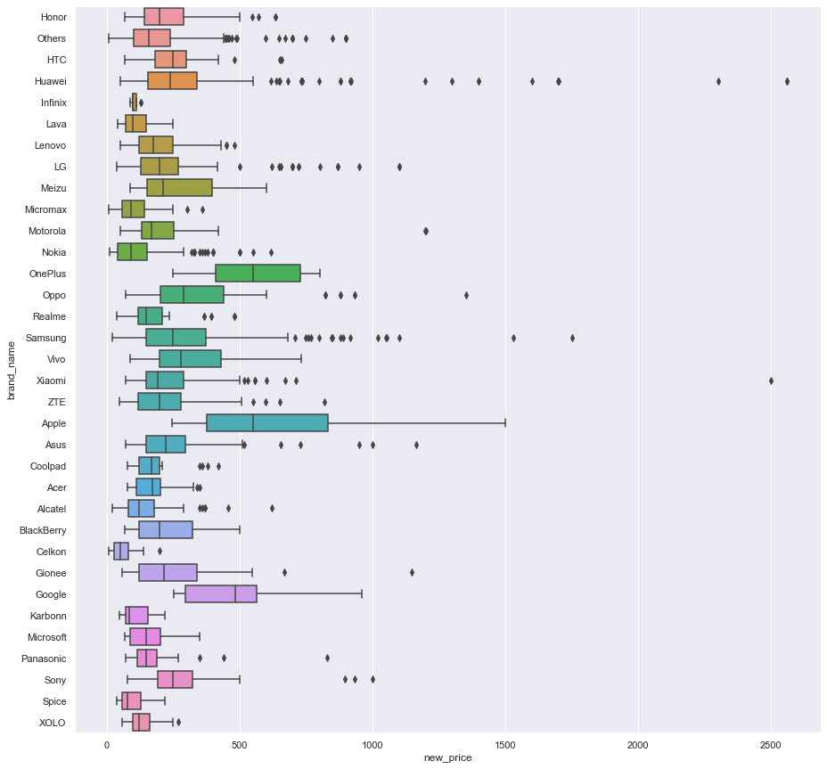

```python
fig, ax = plt.subplots(figsize=(15, 15))
ax = sns.boxplot(dfused["new_price"], dfused["brand_name"], orient="h")
plt.show()
```

#### Observations:

- We can observe from the median price of each brands that there is a clear gap between Google, Apple and OnePlus with other brands
- There is no clear segregation on median price of other brands however we will put a median price cap at 200 to bin into different groups

```python
# Create a dataframe for brand and their median new price
newprice_median_bybrand = (
    dfused.groupby(by=["brand_name"], as_index=True)
    .median()
    .sort_values("new_price", ascending=False)["new_price"]
    .to_frame("median_nprice")
)
newprice_median_bybrand
```

| brand_name | median_nprice |
| --- | --- |
| OnePlus | 550.674 |
| Apple | 550.090 |
| Google | 483.650 |
| Oppo | 290.860 |
| Vivo | 279.650 |
| Sony | 250.800 |
| Samsung | 249.250 |
| HTC | 248.345 |
| Huawei | 240.620 |
| Asus | 221.230 |
| Gionee | 214.945 |
| Meizu | 214.440 |
| BlackBerry | 200.405 |
| Honor | 200.100 |
| LG | 199.790 |
| ZTE | 198.450 |
| Xiaomi | 192.435 |
| Lenovo | 174.565 |
| Acer | 171.700 |
| Coolpad | 170.575 |
| Motorola | 170.126 |
| Others | 159.840 |
| Microsoft | 150.550 |
| Realme | 150.020 |
| Panasonic | 148.440 |
| Alcatel | 121.390 |
| XOLO | 120.930 |
| Infinix | 100.050 |
| Lava | 99.235 |
| Micromax | 90.895 |
| Nokia | 90.530 |
| Karbonn | 85.350 |
| Spice | 80.380 |
| Celkon | 51.130 |

```python
newprice_median_bybrand = newprice_median_bybrand.reset_index()
newprice_median_bybrand
```

|  | brand_name | median_nprice |
| --- | --- | --- |
| 0 | OnePlus | 550.674 |
| 1 | Apple | 550.090 |
| 2 | Google | 483.650 |
| 3 | Oppo | 290.860 |
| 4 | Vivo | 279.650 |
| 5 | Sony | 250.800 |
| 6 | Samsung | 249.250 |
| 7 | HTC | 248.345 |
| 8 | Huawei | 240.620 |
| 9 | Asus | 221.230 |
| 10 | Gionee | 214.945 |
| 11 | Meizu | 214.440 |
| 12 | BlackBerry | 200.405 |
| 13 | Honor | 200.100 |
| 14 | LG | 199.790 |
| 15 | ZTE | 198.450 |
| 16 | Xiaomi | 192.435 |
| 17 | Lenovo | 174.565 |
| 18 | Acer | 171.700 |
| 19 | Coolpad | 170.575 |
| 20 | Motorola | 170.126 |
| 21 | Others | 159.840 |
| 22 | Microsoft | 150.550 |
| 23 | Realme | 150.020 |
| 24 | Panasonic | 148.440 |
| 25 | Alcatel | 121.390 |
| 26 | XOLO | 120.930 |
| 27 | Infinix | 100.050 |
| 28 | Lava | 99.235 |
| 29 | Micromax | 90.895 |
| 30 | Nokia | 90.530 |
| 31 | Karbonn | 85.350 |
| 32 | Spice | 80.380 |
| 33 | Celkon | 51.130 |

```python
# Below code will create a new column phone type in the dataframe to classify each brand as budget, midrange or highend
# based their median price
newprice_median_bybrand["phone_type"] = np.where(
    (newprice_median_bybrand["median_nprice"] < 200), "budget", "default"
)
newprice_median_bybrand["phone_type"] = np.where(
    (
        (newprice_median_bybrand["median_nprice"] >= 200)
        & (newprice_median_bybrand["median_nprice"] <= 400)
        & (newprice_median_bybrand["phone_type"] != "budget")
    ),
    "midrange",
    newprice_median_bybrand["phone_type"],
)
newprice_median_bybrand["phone_type"] = np.where(
    (newprice_median_bybrand["median_nprice"] > 400),
    "highend",
    newprice_median_bybrand["phone_type"],
)
newprice_median_bybrand
```

|  | brand_name | median_nprice | phone_type |
| --- | --- | --- | --- |
| 0 | OnePlus | 550.674 | highend |
| 1 | Apple | 550.090 | highend |
| 2 | Google | 483.650 | highend |
| 3 | Oppo | 290.860 | midrange |
| 4 | Vivo | 279.650 | midrange |
| 5 | Sony | 250.800 | midrange |
| 6 | Samsung | 249.250 | midrange |
| 7 | HTC | 248.345 | midrange |
| 8 | Huawei | 240.620 | midrange |
| 9 | Asus | 221.230 | midrange |
| 10 | Gionee | 214.945 | midrange |
| 11 | Meizu | 214.440 | midrange |
| 12 | BlackBerry | 200.405 | midrange |
| 13 | Honor | 200.100 | midrange |
| 14 | LG | 199.790 | budget |
| 15 | ZTE | 198.450 | budget |
| 16 | Xiaomi | 192.435 | budget |
| 17 | Lenovo | 174.565 | budget |
| 18 | Acer | 171.700 | budget |
| 19 | Coolpad | 170.575 | budget |
| 20 | Motorola | 170.126 | budget |
| 21 | Others | 159.840 | budget |
| 22 | Microsoft | 150.550 | budget |
| 23 | Realme | 150.020 | budget |
| 24 | Panasonic | 148.440 | budget |
| 25 | Alcatel | 121.390 | budget |
| 26 | XOLO | 120.930 | budget |
| 27 | Infinix | 100.050 | budget |
| 28 | Lava | 99.235 | budget |
| 29 | Micromax | 90.895 | budget |
| 30 | Nokia | 90.530 | budget |
| 31 | Karbonn | 85.350 | budget |
| 32 | Spice | 80.380 | budget |
| 33 | Celkon | 51.130 | budget |

```python
# Create list of brand names based on their type, this will be used for binning on the dataset
budget_brands = list(
    newprice_median_bybrand[newprice_median_bybrand["phone_type"] == "budget"][
        "brand_name"
    ]
)
midrange_brands = list(
    newprice_median_bybrand[newprice_median_bybrand["phone_type"] == "midrange"][
        "brand_name"
    ]
)
highend_brands = list(
    newprice_median_bybrand[newprice_median_bybrand["phone_type"] == "highend"][
        "brand_name"
    ]
)
```

```python
dfused["phone_type_bymedian"] = dfused["brand_name"] #to avoid updating the brand_name column creating a new column with same value
dfused
```

|  | brand_name | os | screen_size | 4g | 5g | main_camera_mp | selfie_camera_mp | int_memory | ram | battery | weight | release_year | days_used | new_price | used_price | screen_size_in | phone_type | phone_type_bymedian |
| --- | --- | --- | --- | --- | --- | --- | --- | --- | --- | --- | --- | --- | --- | --- | --- | --- | --- | --- |
| 0 | Honor | Android | 23.970 | yes | no | 13.000 | 5.000 | 64.000 | 3.000 | 3020.000 | 146.000 | 2020 | 127 | 111.620 | 86.960 | 9.437 | budget | Honor |
| 1 | Honor | Android | 28.100 | yes | yes | 13.000 | 16.000 | 128.000 | 8.000 | 4300.000 | 213.000 | 2020 | 325 | 249.390 | 161.490 | 11.063 | midrange | Honor |
| 2 | Honor | Android | 24.290 | yes | yes | 13.000 | 8.000 | 128.000 | 8.000 | 4200.000 | 213.000 | 2020 | 162 | 359.470 | 268.550 | 9.563 | midrange | Honor |
| 3 | Honor | Android | 26.040 | yes | yes | 13.000 | 8.000 | 64.000 | 6.000 | 7250.000 | 480.000 | 2020 | 345 | 278.930 | 180.230 | 10.252 | midrange | Honor |
| 4 | Honor | Android | 15.720 | yes | no | 13.000 | 8.000 | 64.000 | 3.000 | 5000.000 | 185.000 | 2020 | 293 | 140.870 | 103.800 | 6.189 | budget | Honor |
| ... | ... | ... | ... | ... | ... | ... | ... | ... | ... | ... | ... | ... | ... | ... | ... | ... | ... | ... |
| 3566 | Asus | Android | 15.880 | yes | no | 8.000 | 8.000 | 64.000 | 6.000 | 5000.000 | 190.000 | 2019 | 232 | 654.500 | 490.960 | 6.252 | highend | Asus |
| 3567 | Asus | Android | 15.240 | yes | no | 13.000 | 8.000 | 128.000 | 8.000 | 4000.000 | 200.000 | 2018 | 541 | 518.814 | 259.300 | 6.000 | highend | Asus |
| 3568 | Alcatel | Android | 18.730 | yes | no | 13.000 | 5.000 | 32.000 | 3.000 | 4000.000 | 165.000 | 2020 | 201 | 92.650 | 69.810 | 7.374 | budget | Alcatel |
| 3569 | Alcatel | Android | 18.730 | yes | no | 13.000 | 5.000 | 32.000 | 2.000 | 4000.000 | 160.000 | 2020 | 149 | 101.915 | 76.070 | 7.374 | budget | Alcatel |
| 3570 | Alcatel | Android | 13.490 | yes | no | 13.000 | 5.000 | 16.000 | 2.000 | 4000.000 | 168.000 | 2020 | 176 | 72.241 | 50.480 | 5.311 | budget | Alcatel |

3571 rows × 18 columns

```python
# Below code will update the phone_type_bymedian column to bin the brands in types
dfused["phone_type_bymedian"] = dfused["phone_type_bymedian"].replace(
    budget_brands, "budget"
)
dfused["phone_type_bymedian"] = dfused["phone_type_bymedian"].replace(
    midrange_brands, "midrange"
)
dfused["phone_type_bymedian"] = dfused["phone_type_bymedian"].replace(
    highend_brands, "highend"
)
dfused
```

|  | brand_name | os | screen_size | 4g | 5g | main_camera_mp | selfie_camera_mp | int_memory | ram | battery | weight | release_year | days_used | new_price | used_price | screen_size_in | phone_type | phone_type_bymedian |
| --- | --- | --- | --- | --- | --- | --- | --- | --- | --- | --- | --- | --- | --- | --- | --- | --- | --- | --- |
| 0 | Honor | Android | 23.970 | yes | no | 13.000 | 5.000 | 64.000 | 3.000 | 3020.000 | 146.000 | 2020 | 127 | 111.620 | 86.960 | 9.437 | budget | midrange |
| 1 | Honor | Android | 28.100 | yes | yes | 13.000 | 16.000 | 128.000 | 8.000 | 4300.000 | 213.000 | 2020 | 325 | 249.390 | 161.490 | 11.063 | midrange | midrange |
| 2 | Honor | Android | 24.290 | yes | yes | 13.000 | 8.000 | 128.000 | 8.000 | 4200.000 | 213.000 | 2020 | 162 | 359.470 | 268.550 | 9.563 | midrange | midrange |
| 3 | Honor | Android | 26.040 | yes | yes | 13.000 | 8.000 | 64.000 | 6.000 | 7250.000 | 480.000 | 2020 | 345 | 278.930 | 180.230 | 10.252 | midrange | midrange |
| 4 | Honor | Android | 15.720 | yes | no | 13.000 | 8.000 | 64.000 | 3.000 | 5000.000 | 185.000 | 2020 | 293 | 140.870 | 103.800 | 6.189 | budget | midrange |
| ... | ... | ... | ... | ... | ... | ... | ... | ... | ... | ... | ... | ... | ... | ... | ... | ... | ... | ... |
| 3566 | Asus | Android | 15.880 | yes | no | 8.000 | 8.000 | 64.000 | 6.000 | 5000.000 | 190.000 | 2019 | 232 | 654.500 | 490.960 | 6.252 | highend | midrange |
| 3567 | Asus | Android | 15.240 | yes | no | 13.000 | 8.000 | 128.000 | 8.000 | 4000.000 | 200.000 | 2018 | 541 | 518.814 | 259.300 | 6.000 | highend | midrange |
| 3568 | Alcatel | Android | 18.730 | yes | no | 13.000 | 5.000 | 32.000 | 3.000 | 4000.000 | 165.000 | 2020 | 201 | 92.650 | 69.810 | 7.374 | budget | budget |
| 3569 | Alcatel | Android | 18.730 | yes | no | 13.000 | 5.000 | 32.000 | 2.000 | 4000.000 | 160.000 | 2020 | 149 | 101.915 | 76.070 | 7.374 | budget | budget |
| 3570 | Alcatel | Android | 13.490 | yes | no | 13.000 | 5.000 | 16.000 | 2.000 | 4000.000 | 168.000 | 2020 | 176 | 72.241 | 50.480 | 5.311 | budget | budget |

3571 rows × 18 columns

## EDA Contd..

- Now that we have classified the dataset in phone types by the median price range of brands, let's explore the budget phones which offer great selfie cameras(>8MP) one more time

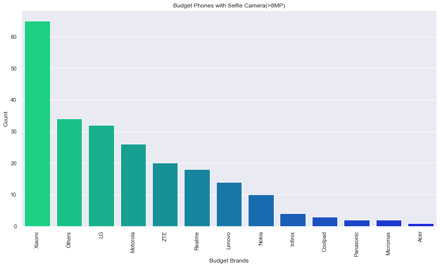

```python
# Plotting countplot to visualize the unique brands available under budget phones who offer >8MP selfie camera
fig, ax = plt.subplots(figsize=(15, 8))
ax = sns.countplot(
    dfused[
        (dfused["phone_type_bymedian"] == "budget") & (dfused["selfie_camera_mp"] > 8)
    ]["brand_name"],
    palette="winter_r",
    ax=ax,
    order=dfused[
        (dfused["phone_type_bymedian"] == "budget") & (dfused["selfie_camera_mp"] > 8)
    ]["brand_name"]
    .value_counts()
    .index,
)
ax.set_title("Budget Phones with Selfie Camera(>8MP)")
ax.set_xticklabels(ax.get_xticklabels(), rotation=90)
plt.xlabel(f"Budget Brands")
plt.ylabel("Count")
plt.show()
```

#### Observations:

- Xiaomi is still clearly the market leader in budget phones which offers great selfie cameras(>8MP)
- Acer offers the least value among budget phones in terms of great selfie cameras

## Data Preprocessing Contd...

- Let's continue with Data preprocessing and we will explore the dataset again after the same

### As we have observed earlier we have outliers in multiple columns, let's try to identify and treat them all before proceeding

```python
# Before we manipulate the data let's take a copy of the dataset, so that for any issues we can restore and rerun
# below steps (***Do not run this step if restoration is not required***)
dfused_bkup_affeatureeng = dfused.copy()
```

### Let's plot boxplots to check which columns have outliers

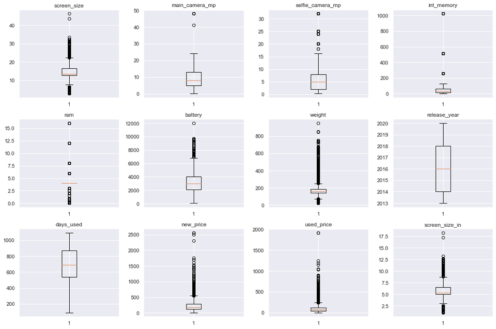

```python
numeric_columns = dfused.select_dtypes(include=np.number).columns.tolist()
# let's plot the boxplots of all columns to check for outliers
plt.figure(figsize=(15, 10))

for i, variable in enumerate(numeric_columns):
    plt.subplot(3, 4, i + 1)
    plt.boxplot(dfused[variable], whis=1.5)
    plt.tight_layout()
    plt.title(variable)

plt.show()
```

#### Observations:

- Except release year and days used, all the columns has outliers.
- Screen size, ram, and weight has outliers on lower and upper side
- Since we observed ram has 1st and 3rd quantiale as 4, the plot shows a single line as whiskers and all other values as outliers.
- All other numerical columns has upper outliers
- Even though we have outliers in used_price columns we will not treat it as it's our target variable and we want to fit our model with observed values and test performance against the same.

#### Let's write a function to treat all the outliers

```python
def treat_outliers(df, col):
    """
    treats outliers in a variable
    col: str, name of the numerical variable
    df: dataframe
    col: name of the column
    """
    Q1 = df[col].quantile(0.25)  # 25th quantile
    Q3 = df[col].quantile(0.75)  # 75th quantile
    IQR = Q3 - Q1
    Lower_Whisker = Q1 - 1.5 * IQR
    Upper_Whisker = Q3 + 1.5 * IQR

    # all the values smaller than Lower_Whisker will be assigned the value of Lower_Whisker
    # all the values greater than Upper_Whisker will be assigned the value of Upper_Whisker
    df[col] = np.clip(df[col], Lower_Whisker, Upper_Whisker)

    return df


def treat_outliers_all(df, col_list):
    """
    treat outlier in all numerical variables
    col_list: list of numerical variables
    df: data frame
    """
    for c in col_list:
        df = treat_outliers(df, c)

    return df
```

```python
# Create a filtered list of numeric columns except ram
numeric_columns_filtered = dfused.select_dtypes(include=np.number).columns.tolist()
numeric_columns_filtered.remove("ram")
numeric_columns_filtered
```

```
['screen_size',
 'main_camera_mp',
 'selfie_camera_mp',
 'int_memory',
 'battery',
 'weight',
 'release_year',
 'days_used',
 'new_price',
 'used_price',
 'screen_size_in']
```

```python
# treating the outliers except ram
dfused = treat_outliers_all(dfused, numeric_columns_filtered)
dfused
```

|  | brand_name | os | screen_size | 4g | 5g | main_camera_mp | selfie_camera_mp | int_memory | ram | battery | weight | release_year | days_used | new_price | used_price | screen_size_in | phone_type | phone_type_bymedian |
| --- | --- | --- | --- | --- | --- | --- | --- | --- | --- | --- | --- | --- | --- | --- | --- | --- | --- | --- |
| 0 | Honor | Android | 22.225 | yes | no | 13.000 | 5.000 | 64.000 | 3.000 | 3020.000 | 146.000 | 2020 | 127 | 111.620 | 86.960 | 8.750 | budget | midrange |
| 1 | Honor | Android | 22.225 | yes | yes | 13.000 | 16.000 | 128.000 | 8.000 | 4300.000 | 213.000 | 2020 | 325 | 249.390 | 161.490 | 8.750 | midrange | midrange |
| 2 | Honor | Android | 22.225 | yes | yes | 13.000 | 8.000 | 128.000 | 8.000 | 4200.000 | 213.000 | 2020 | 162 | 359.470 | 247.192 | 8.750 | midrange | midrange |
| 3 | Honor | Android | 22.225 | yes | yes | 13.000 | 8.000 | 64.000 | 6.000 | 6850.000 | 250.000 | 2020 | 345 | 278.930 | 180.230 | 8.750 | midrange | midrange |
| 4 | Honor | Android | 15.720 | yes | no | 13.000 | 8.000 | 64.000 | 3.000 | 5000.000 | 185.000 | 2020 | 293 | 140.870 | 103.800 | 6.189 | budget | midrange |
| ... | ... | ... | ... | ... | ... | ... | ... | ... | ... | ... | ... | ... | ... | ... | ... | ... | ... | ... |
| 3566 | Asus | Android | 15.880 | yes | no | 8.000 | 8.000 | 64.000 | 6.000 | 5000.000 | 190.000 | 2019 | 232 | 549.642 | 247.192 | 6.252 | highend | midrange |
| 3567 | Asus | Android | 15.240 | yes | no | 13.000 | 8.000 | 128.000 | 8.000 | 4000.000 | 200.000 | 2018 | 541 | 518.814 | 247.192 | 6.000 | highend | midrange |
| 3568 | Alcatel | Android | 18.730 | yes | no | 13.000 | 5.000 | 32.000 | 3.000 | 4000.000 | 165.000 | 2020 | 201 | 92.650 | 69.810 | 7.374 | budget | budget |
| 3569 | Alcatel | Android | 18.730 | yes | no | 13.000 | 5.000 | 32.000 | 2.000 | 4000.000 | 160.000 | 2020 | 149 | 101.915 | 76.070 | 7.374 | budget | budget |
| 3570 | Alcatel | Android | 13.490 | yes | no | 13.000 | 5.000 | 16.000 | 2.000 | 4000.000 | 168.000 | 2020 | 176 | 72.241 | 50.480 | 5.311 | budget | budget |

3571 rows × 18 columns

### Let's check if we have now treated all outliers except used_price

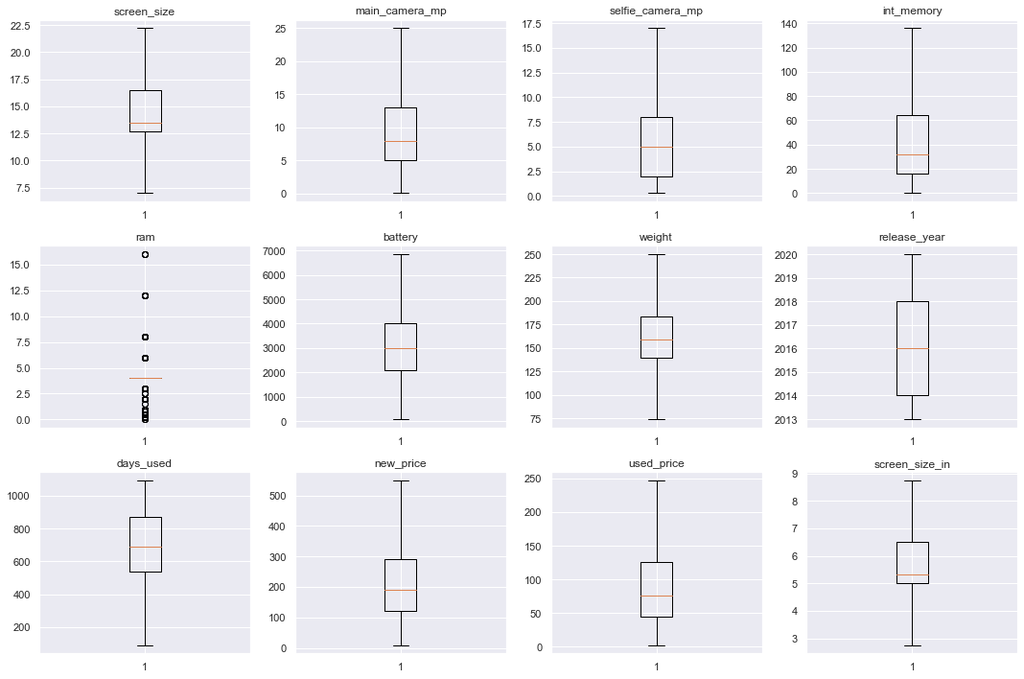

```python
# Let's check if the outliers are treated properly
# let's plot the boxplots of all columns to check for outliers
plt.figure(figsize=(15, 10))

for i, variable in enumerate(numeric_columns):
    plt.subplot(3, 4, i + 1)
    plt.boxplot(dfused[variable], whis=1.5)
    plt.tight_layout()
    plt.title(variable)

plt.show()
```

#### Observations:

- We can see we have succesfully treated all the outliers except ram as intended to keep it unchanged since it is a discreet variable.(Clarification provided, we do not have to do outlier treatment for discreet variable)
- For each numerical columns which had outliers, any values lower than lower whisker value replaced with value of lower whisker, and any value upper than upper whisker value replaced with upper whisker value

## EDA Contd...

- Before we proceed building model let's revisit and explore the the variables since we have manupulated data, created new features.

### Visualizing the categorical columns

#### Let's check the proprotions of data in the new feature we added, phone_type_bymedian

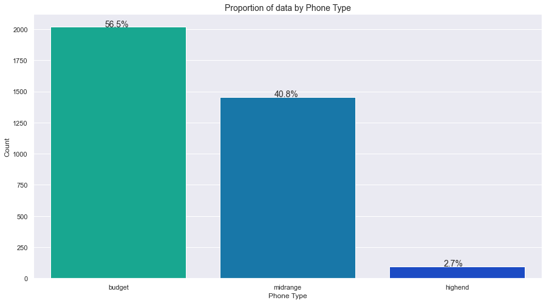

```python
fig, ax = plt.subplots(figsize=(15, 8))
ax = sns.countplot(
    dfused["phone_type_bymedian"],
    palette="winter_r",
    ax=ax,
    order=dfused["phone_type_bymedian"].value_counts().index,
)  # plotting first subplot
ax.set_title("Proportion of data by Phone Type", fontsize=14)
ax.set_xticklabels(ax.get_xticklabels())
plt.xlabel(f"Phone Type")
plt.ylabel("Count")
# perc_annot(ax1,dfused['brand_name']) #perc_annot() function is used to show the percentages annotation
tot = len(dfused["phone_type_bymedian"])
for p in ax.patches:
    percentage = "{:.1f}%".format(
        100 * p.get_height() / tot
    )  # percentage of each class of the category
    x = p.get_x() + p.get_width() / 2.5  # width of the plot
    y = p.get_y() + p.get_height() + 1  # hieght of the plot
    ax.annotate(percentage, (x, y), size=14)  # annotate the percantage
```

#### Observations:

- Budget phones are the most popular in used phone market, we can observe they are almost ~56% of the data given.
- High end phones in used market is only about ~3% , where as mid range phones has close to 41% of observations

### We don't expect any changes in os, 4g, 5g data proportions, let's confirm that

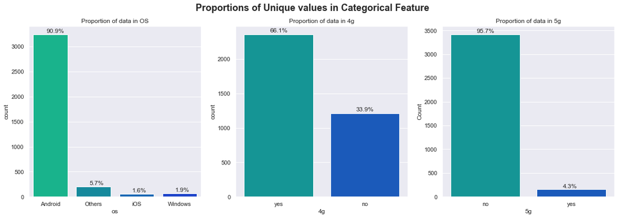

```python
fig, (ax1, ax2, ax3) = plt.subplots(
    1, 3, figsize=(20, 6)
)  # Create 2 rows and 2 column wise subplots

ax = sns.countplot(dfused["os"], palette="winter_r", ax=ax1)  # plotting second subplot
ax.set_title("Proportion of data in OS")
plt.ylabel("Count")
perc_annot(ax1, dfused["os"])
ax = sns.countplot(dfused["4g"], palette="winter_r", ax=ax2)  # plotting third subplot
ax.set_title("Proportion of data in 4g")
plt.ylabel("Count")
perc_annot(ax2, dfused["4g"])
ax = sns.countplot(dfused["5g"], palette="winter_r", ax=ax3)  # plotting fourth subplot
ax.set_title("Proportion of data in 5g")
plt.ylabel("Count")
perc_annot(ax3, dfused["5g"])
plt.suptitle(
    "Proportions of Unique values in Categorical Feature",
    fontsize=18,
    fontweight="bold",
)
plt.show()
```

#### Observations -

- Android os phones are predominant in the dataset, close to ~91%, with second highest proportion for phones having os other than android, ios and windows
- ios and windows os phones have the lowest proportions.
- Majority ~66% phones have 4g
- Majority ~96% phones doesn't have 5g
- We can observe there's no change in the proportions on these variables, it confirms our data preprocessing has not wrangled any data proportions in these columns

### Visualizing some numerical columns

### Let's check distributions for all columns after treating outliers

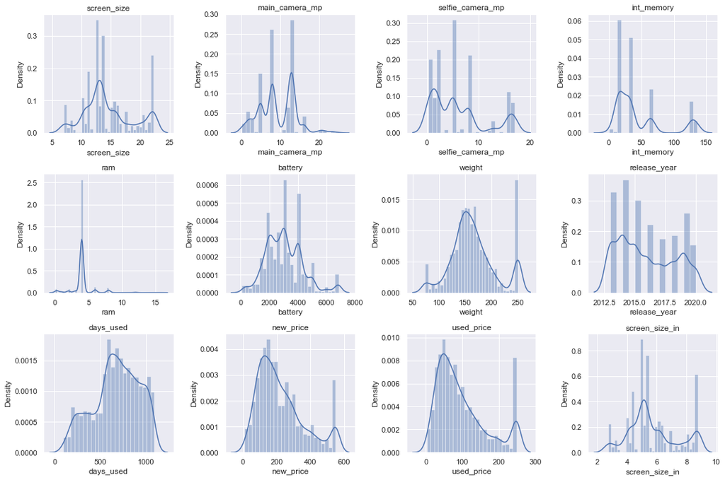

```python
plt.figure(figsize=(15, 10))

for i, variable in enumerate(numeric_columns):
    plt.subplot(3, 4, i + 1)
    sns.distplot(dfused[variable])
    plt.tight_layout()
    plt.title(variable)

plt.show()
```

#### Observations:

- After treating outliers, we can observe minot change in distribution but no additional observation other than range range.
- We can observe a peak at the begining and end of the weight and screen size distributions, that is because we have treated both upper and lower outliers and the data range now shows as ~75grams to ~250grams for weight and ~3inch to ~8.5inch for screen size

### Let's check the correlation matrix now

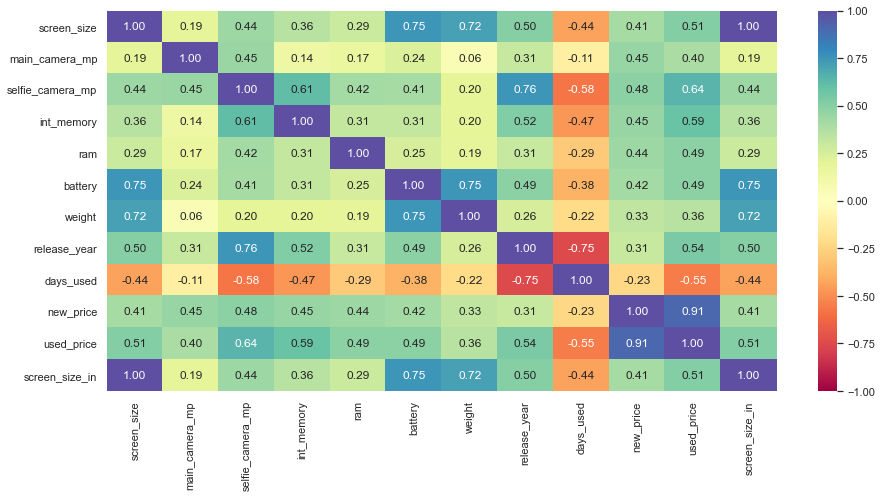

```python
# correlation heatmap
plt.figure(figsize=(15, 7))
sns.heatmap(
    dfused.corr(), annot=True, vmin=-1, vmax=1, fmt=".2f", cmap="Spectral",
)
plt.show()
```

### Let's plot the relationship of the variables we observed correlated with used_price

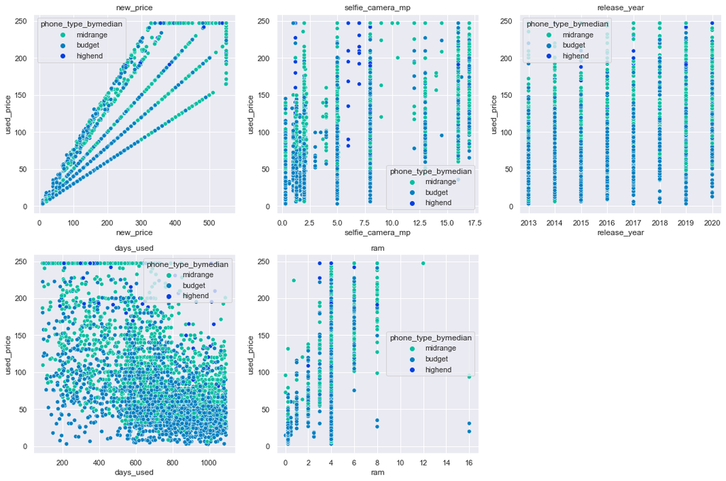

```python
plt.figure(figsize=(15, 10))
for i, x in enumerate(
    ["new_price", "selfie_camera_mp", "release_year", "days_used", "ram"]
):
    plt.subplot(2, 3, i + 1)
    sns.scatterplot(
        dfused[x],
        dfused["used_price"],
        palette="winter_r",
        hue=dfused["phone_type_bymedian"],
    )
    plt.tight_layout()
    plt.title(x)

plt.show()
```

#### Observations:

- As we have observed from correlation from this plots we can observe used phone price is increase as new phone price goes higher
- With better selfie camera the used phone price increases
- The newer the phone is the price of used phone will increase, though it's not clearly visible in plot, but from correlation we can get an idea.
- Used phone price will decrease based on how many days it was used prior
- With higher ram in the phone the used phone price increase

### Let's revisit the key questions we have answered before, and check if there's any change

- We have already answered the question on what percentage of used phone market is dominated by Android, it's ~91%
- We have also seen the distribution of used_price after treating outliers.
- For distribution of budget phones offering >8MP selfie camera, we have seen it through a plot after newly created bins
- We have also observed the correleated variables with used price through previous visualizations
- For rest of them let's revisit

### Let's explore how the amount of RAM vary with Brand

```python
# Creating a frame where Brand name is index and average ram as a column sorted in descending order, this
# will help in visualization order as well.
rambybrand_af = (
    dfused.groupby(by=["brand_name"], as_index=True)
    .mean()
    .sort_values("ram", ascending=False)["ram"]
    .to_frame("ram")
)
```

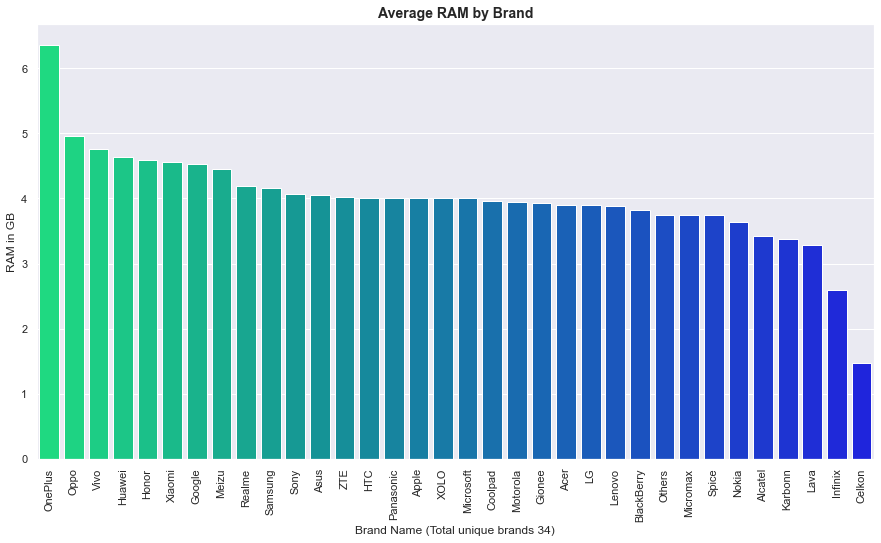

```python
fig, ax = plt.subplots(figsize=(15, 8))
ax = sns.barplot(
    dfused["brand_name"],
    dfused["ram"],
    palette="winter_r",
    ax=ax,
    ci=0,
    estimator=np.mean,
    order=rambybrand_af.index,
)  # plotting first subplot
ax.set_title("Average RAM by Brand", fontweight="bold", fontsize=14)
ax.set_xticklabels(ax.get_xticklabels(), rotation=90)
plt.xlabel(f"Brand Name (Total unique brands {ub})")
plt.ylabel("RAM in GB")
plt.show()
```

#### Observations:

- There is no change to observe than what we have observed before

#### Let's explore how the weight vary for phones with larger battery (>4500mAh)

```python
largebattery_af = dfused[
    dfused["battery"] > 4500
]  # Filtered dataframe for large battery phones
```

```python
# calculating the percentage of larger battery phones
large_bat_perc_af = len(largebattery_af["battery"]) / len(dfused["battery"]) * 100
print(
    f"There are {np.round(large_bat_perc_af,1)}% of phones having larger battery(>4500mAh)"
)
```

```
There are 9.7% of phones having larger battery(>4500mAh)
```

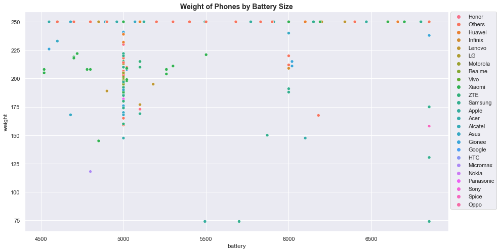

```python
# Plot a scatter plot to check the how the weight varies by the battery size
fig, ax = plt.subplots(figsize=(15, 8))
ax = sns.scatterplot(x="battery", y="weight", data=largebattery_af, hue="brand_name")
ax.set_title("Weight of Phones by Battery Size", fontweight="bold", fontsize=14)
plt.legend(bbox_to_anchor=(1.005, 1), loc=2, borderaxespad=0.0)
plt.show()
```

#### Observations:

- After treating outliers and missing values we can observe changes in the patterns for bigger battery phones
- As we have treated the outliers the weight which had many outliers on the upper side now show up in the plot as straight horizontal points as they are treated with upper whisker value
- The other observations for higher battery phones remain same, as the battery size increase, the weight increases.

### Let's check how many phones have larger screens (> 6 inch) across brands

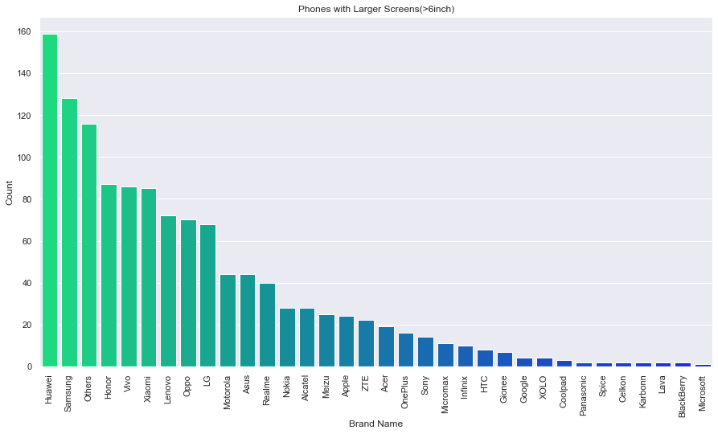

```python
fig, ax = plt.subplots(figsize=(15, 8))
ax = sns.countplot(
    dfused[dfused["screen_size_in"] > 6]["brand_name"],
    palette="winter_r",
    ax=ax,
    order=dfused[dfused["screen_size_in"] > 6]["brand_name"].value_counts().index,
)  # plotting first subplot
ax.set_title("Phones with Larger Screens(>6inch)")
ax.set_xticklabels(ax.get_xticklabels(), rotation=90)
plt.xlabel(f"Brand Name")
plt.ylabel("Count")
plt.show()
```

#### Observations:

- We can see there are no changes on this observation than previously observed.

### Let's check which brand of phones in budget phones

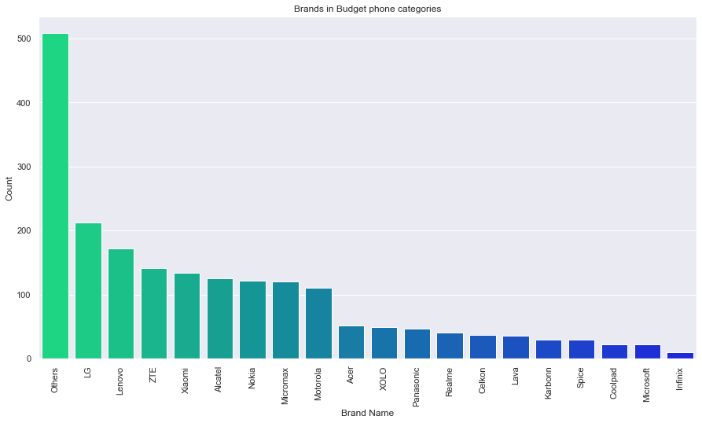

```python
fig, ax1 = plt.subplots(figsize=(15, 8))
ax = sns.countplot(
    dfused[dfused["phone_type_bymedian"] == "budget"]["brand_name"],
    palette="winter_r",
    ax=ax1,
    order=dfused[dfused["phone_type_bymedian"] == "budget"]["brand_name"]
    .value_counts()
    .index,
)  # plotting first subplot
ax.set_title("Brands in Budget phone categories")
ax.set_xticklabels(ax.get_xticklabels(), rotation=90)
plt.xlabel(f"Brand Name")
plt.ylabel("Count")
plt.show()
```

#### Observations:

- Since it's not possible to know what are different brands present in others brand type we will not consider that for drawing this insight
- In Budget phones(average new price < 200 euros) LG is the most popular brand.

## Data Preparation for Modeling

#### Let's take another backup before start preparing the data for our model

```python
dfused_bkup_beforemodel = dfused.copy()
```

#### Let's take a quick look at the columns we have in our data

```python
dfused.info()
```

```
<class 'pandas.core.frame.DataFrame'>
RangeIndex: 3571 entries, 0 to 3570
Data columns (total 18 columns):
 #   Column               Non-Null Count  Dtype
---  ------               --------------  -----
 0   brand_name           3571 non-null   object
 1   os                   3571 non-null   object
 2   screen_size          3571 non-null   float64
 3   4g                   3571 non-null   object
 4   5g                   3571 non-null   object
 5   main_camera_mp       3571 non-null   float64
 6   selfie_camera_mp     3571 non-null   float64
 7   int_memory           3571 non-null   float64
 8   ram                  3571 non-null   float64
 9   battery              3571 non-null   float64
 10  weight               3571 non-null   float64
 11  release_year         3571 non-null   int64
 12  days_used            3571 non-null   int64
 13  new_price            3571 non-null   float64
 14  used_price           3571 non-null   float64
 15  screen_size_in       3571 non-null   float64
 16  phone_type           3571 non-null   object
 17  phone_type_bymedian  3571 non-null   object
dtypes: float64(10), int64(2), object(6)
memory usage: 502.3+ KB
```

#### Observations:

- Since we have bin the brand name into phone_type_bymedian column, we wouldn't need this column to feed in our model
- We will use screen_size_in column which we have tranformed from cm to in from screen_size column
- We wouldn't need the phone_type column anymore as we have further binned by median in phone_type_bymedian column

### Let's drop the columns noted above which are not required

```python
cols_to_drop = ["brand_name", "screen_size", "phone_type"]
dfused = dfused.drop(cols_to_drop, axis=1)
dfused.info()
```

```
<class 'pandas.core.frame.DataFrame'>
RangeIndex: 3571 entries, 0 to 3570
Data columns (total 15 columns):
 #   Column               Non-Null Count  Dtype
---  ------               --------------  -----
 0   os                   3571 non-null   object
 1   4g                   3571 non-null   object
 2   5g                   3571 non-null   object
 3   main_camera_mp       3571 non-null   float64
 4   selfie_camera_mp     3571 non-null   float64
 5   int_memory           3571 non-null   float64
 6   ram                  3571 non-null   float64
 7   battery              3571 non-null   float64
 8   weight               3571 non-null   float64
 9   release_year         3571 non-null   int64
 10  days_used            3571 non-null   int64
 11  new_price            3571 non-null   float64
 12  used_price           3571 non-null   float64
 13  screen_size_in       3571 non-null   float64
 14  phone_type_bymedian  3571 non-null   object
dtypes: float64(9), int64(2), object(4)
memory usage: 418.6+ KB
```

#### Observations:

- Columns are dropped

### Let's now define our X and y data

```python
# X are the independent variables and y will be our target/dependent variable
X = dfused.drop("used_price", axis=1)
y = dfused["used_price"]
```

- Quick check on X and y data

```python
X.head()
```

|  | os | 4g | 5g | main_camera_mp | selfie_camera_mp | int_memory | ram | battery | weight | release_year | days_used | new_price | screen_size_in | phone_type_bymedian |
| --- | --- | --- | --- | --- | --- | --- | --- | --- | --- | --- | --- | --- | --- | --- |
| 0 | Android | yes | no | 13.000 | 5.000 | 64.000 | 3.000 | 3020.000 | 146.000 | 2020 | 127 | 111.620 | 8.750 | midrange |
| 1 | Android | yes | yes | 13.000 | 16.000 | 128.000 | 8.000 | 4300.000 | 213.000 | 2020 | 325 | 249.390 | 8.750 | midrange |
| 2 | Android | yes | yes | 13.000 | 8.000 | 128.000 | 8.000 | 4200.000 | 213.000 | 2020 | 162 | 359.470 | 8.750 | midrange |
| 3 | Android | yes | yes | 13.000 | 8.000 | 64.000 | 6.000 | 6850.000 | 250.000 | 2020 | 345 | 278.930 | 8.750 | midrange |
| 4 | Android | yes | no | 13.000 | 8.000 | 64.000 | 3.000 | 5000.000 | 185.000 | 2020 | 293 | 140.870 | 6.189 | midrange |

```python
y.head()
```

```
0    86.960
1   161.490
2   247.192
3   180.230
4   103.800
Name: used_price, dtype: float64
```

### Let's now convert all object/categorical data into numerical data using one hot encoding

- We are going to use the drop_first = True of get_dummies method, which will drop one columns from the dummies it create

```python
# Using pandas get_dummies we are converting all categorical data to numerical
X = pd.get_dummies(
    X,
    columns=X.select_dtypes(include=["object", "category"]).columns.tolist(),
    drop_first=True,
)
X.head()
```

|  | main_camera_mp | selfie_camera_mp | int_memory | ram | battery | weight | release_year | days_used | new_price | screen_size_in | os_Others | os_Windows | os_iOS | 4g_yes | 5g_yes | phone_type_bymedian_highend | phone_type_bymedian_midrange |
| --- | --- | --- | --- | --- | --- | --- | --- | --- | --- | --- | --- | --- | --- | --- | --- | --- | --- |
| 0 | 13.000 | 5.000 | 64.000 | 3.000 | 3020.000 | 146.000 | 2020 | 127 | 111.620 | 8.750 | 0 | 0 | 0 | 1 | 0 | 0 | 1 |
| 1 | 13.000 | 16.000 | 128.000 | 8.000 | 4300.000 | 213.000 | 2020 | 325 | 249.390 | 8.750 | 0 | 0 | 0 | 1 | 1 | 0 | 1 |
| 2 | 13.000 | 8.000 | 128.000 | 8.000 | 4200.000 | 213.000 | 2020 | 162 | 359.470 | 8.750 | 0 | 0 | 0 | 1 | 1 | 0 | 1 |
| 3 | 13.000 | 8.000 | 64.000 | 6.000 | 6850.000 | 250.000 | 2020 | 345 | 278.930 | 8.750 | 0 | 0 | 0 | 1 | 1 | 0 | 1 |
| 4 | 13.000 | 8.000 | 64.000 | 3.000 | 5000.000 | 185.000 | 2020 | 293 | 140.870 | 6.189 | 0 | 0 | 0 | 1 | 0 | 0 | 1 |

#### Observations:

- We can see that all the categorical columns are not converted into numerical based on their unique values dummy columns are added with one hot encoded as values.
- Since we chose to drop first, it has dropped one unique value column in this process, for ex- we can't see the budget phone type column but the other two are there.

### Now let's split the data in train and test for our model to fit and train and then check performance on test

- We will split the data as train set contains 70% of data randomly chosen, and test set will have 30% of data

```python
# splitting the data in 70:30 ratio for train to test data

x_train, x_test, y_train, y_test = train_test_split(
    X, y, test_size=0.3, random_state=42
)
```

```python
print("Number of rows in train data =", x_train.shape[0])
print("Number of rows in test data =", x_test.shape[0])
```

```
Number of rows in train data = 2499
Number of rows in test data = 1072
```

### Now let's build the Linear Regression model using sklearn

```python
# fitting the model on the train data (70% of the whole data)
from sklearn.linear_model import LinearRegression

linearregression = LinearRegression()  # model creation
linearregression.fit(x_train, y_train)  # model fit/train
```

```
LinearRegression()
```

#### Let's check the coefficients and intercept of the model.

```python
# creating a dataframe to display the coefficients with column names
coef_df = pd.DataFrame(
    np.append(linearregression.coef_, linearregression.intercept_),
    index=x_train.columns.tolist() + ["Intercept"],
    columns=["Coefficients"],
)

coef_df
```

|  | Coefficients |
| --- | --- |
| main_camera_mp | -0.183 |
| selfie_camera_mp | 0.706 |
| int_memory | 0.087 |
| ram | 0.331 |
| battery | 0.000 |
| weight | -0.006 |
| release_year | -0.208 |
| days_used | -0.085 |
| new_price | 0.385 |
| screen_size_in | 0.502 |
| os_Others | -4.399 |
| os_Windows | -1.073 |
| os_iOS | 10.081 |
| 4g_yes | -3.003 |
| 5g_yes | 0.499 |
| phone_type_bymedian_highend | -2.545 |
| phone_type_bymedian_midrange | 0.579 |
| Intercept | 478.354 |

#### Let's check the performance of the model using different metrics.

- We will be using metric functions defined in sklearn for RMSE, MAE, and 𝑅2 .
- We will define a function to calculate MAPE and adjusted 𝑅2 .
- The mean absolute percentage error (MAPE) measures the accuracy of predictions as a percentage, and can be calculated as the average absolute percent error for each predicted value minus actual values divided by actual values. - It works best if there are no extreme values in the data and none of the actual values are 0.
- We will create a function which will print out all the above metrics in one go.

```python
# function to compute adjusted R-squared
def adj_r2_score(predictors, targets, predictions):
    r2 = r2_score(targets, predictions)
    n = predictors.shape[0]
    k = predictors.shape[1]
    return 1 - ((1 - r2) * (n - 1) / (n - k - 1))


# function to compute MAPE
def mape_score(targets, predictions):
    return np.mean(np.abs(targets - predictions) / targets) * 100


# function to compute different metrics to check performance of a regression model
def model_performance_regression(model, predictors, target):
    """
    Function to compute different metrics to check regression model performance

    model: regressor
    predictors: independent variables
    target: dependent variable
    """

    # predicting using the independent variables
    pred = model.predict(predictors)

    r2 = r2_score(target, pred)  # to compute R-squared
    adjr2 = adj_r2_score(predictors, target, pred)  # to compute adjusted R-squared
    rmse = np.sqrt(mean_squared_error(target, pred))  # to compute RMSE
    mae = mean_absolute_error(target, pred)  # to compute MAE
    mape = mape_score(target, pred)  # to compute MAPE

    # creating a dataframe of metrics
    df_perf = pd.DataFrame(
        {
            "RMSE": rmse,
            "MAE": mae,
            "R-squared": r2,
            "Adj. R-squared": adjr2,
            "MAPE": mape,
        },
        index=[0],
    )

    return df_perf
```

```python
# checking model performance on train set (seen 70% data)
print("Training Performance\n")
linearregression_train_perf = model_performance_regression(
    linearregression, x_train, y_train
)
linearregression_train_perf
```

```
Training Performance
```

|  | RMSE | MAE | R-squared | Adj. R-squared | MAPE |
| --- | --- | --- | --- | --- | --- |
| 0 | 14.212 | 10.392 | 0.954 | 0.953 | 18.733 |

```python
# checking model performance on test set (seen 30% data)
print("Test Performance\n")
linearregression_test_perf = model_performance_regression(
    linearregression, x_test, y_test
)
linearregression_test_perf
```

```
Test Performance
```

|  | RMSE | MAE | R-squared | Adj. R-squared | MAPE |
| --- | --- | --- | --- | --- | --- |
| 0 | 13.778 | 10.121 | 0.957 | 0.957 | 16.259 |

#### Observations:

- The training $R^2$ is 95.4%, indicating that the model explains 95.4% of the variation in the train data. So, the model is not underfitting.
- MAE and RMSE on the train and test sets are comparable, which shows that the model is not overfitting.
- MAE indicates that our current model is able to predict used phone price within a mean error of ~10 euro on the test data.
- MAPE on the test set suggests we can predict within ~16% of the used price.

## Let's build Linear Regression model using statsmodel

```python
# unlike sklearn, statsmodels does not add a constant to the data on its own
# we have to add the constant manually
x_train1 = sm.add_constant(x_train, has_constant="add")
# adding constant to the test data
x_test1 = sm.add_constant(x_test, has_constant="add")

olsmod0 = sm.OLS(y_train, x_train1).fit()
print(olsmod0.summary())
```

```
                            OLS Regression Results
==============================================================================
Dep. Variable:             used_price   R-squared:                       0.954
Model:                            OLS   Adj. R-squared:                  0.953
Method:                 Least Squares   F-statistic:                     2993.
Date:                Fri, 20 Aug 2021   Prob (F-statistic):               0.00
Time:                        12:16:23   Log-Likelihood:                -10178.
No. Observations:                2499   AIC:                         2.039e+04
Df Residuals:                    2481   BIC:                         2.050e+04
Df Model:                          17
Covariance Type:            nonrobust
================================================================================================
                                   coef    std err          t      P>|t|      [0.025      0.975]
------------------------------------------------------------------------------------------------
const                          478.3543    542.785      0.881      0.378    -586.005    1542.714
main_camera_mp                  -0.1826      0.087     -2.090      0.037      -0.354      -0.011
selfie_camera_mp                 0.7056      0.103      6.865      0.000       0.504       0.907
int_memory                       0.0868      0.010      8.453      0.000       0.067       0.107
ram                              0.3307      0.266      1.242      0.214      -0.192       0.853
battery                       4.762e-05      0.000      0.111      0.912      -0.001       0.001
weight                          -0.0062      0.012     -0.505      0.614      -0.030       0.018
release_year                    -0.2076      0.269     -0.771      0.441      -0.735       0.320
days_used                       -0.0849      0.002    -46.676      0.000      -0.088      -0.081
new_price                        0.3846      0.003    115.673      0.000       0.378       0.391
screen_size_in                   0.5019      0.312      1.608      0.108      -0.110       1.114
os_Others                       -4.3988      1.391     -3.162      0.002      -7.126      -1.671
os_Windows                      -1.0727      2.107     -0.509      0.611      -5.205       3.059
os_iOS                          10.0813      3.529      2.857      0.004       3.161      17.001
4g_yes                          -3.0033      0.888     -3.383      0.001      -4.744      -1.262
5g_yes                           0.4992      1.883      0.265      0.791      -3.194       4.192
phone_type_bymedian_highend     -2.5454      2.701     -0.943      0.346      -7.841       2.750
phone_type_bymedian_midrange     0.5795      0.640      0.905      0.366      -0.676       1.835
==============================================================================
Omnibus:                      299.237   Durbin-Watson:                   1.971
Prob(Omnibus):                  0.000   Jarque-Bera (JB):              672.950
Skew:                           0.711   Prob(JB):                    7.43e-147
Kurtosis:                       5.108   Cond. No.                     7.30e+06
==============================================================================

Notes:
[1] Standard Errors assume that the covariance matrix of the errors is correctly specified.
[2] The condition number is large, 7.3e+06. This might indicate that there are
strong multicollinearity or other numerical problems.
```

## Checking Linear Regression Assumptions

We will be checking the following Linear Regression assumptions:

1. **No Multicollinearity**
2. **Linearity of variables**
3. **Independence of error terms**
4. **Normality of error terms**
5. **No Heteroscedasticity**

### Test for Multicollinearity

- We will take the following guideline(from general rule and clarification received) while dealing with multicollinearity
1. If VIF is between 1 and 5, then there is low multicollinearity. - Acceptable
2. If VIF is between 5 and 10, we say there is moderate multicollinearity - Acceptable
3. If VIF is exceeding 10, it shows signs of high multicollinearity - Need to drop and test again

```python
from statsmodels.stats.outliers_influence import variance_inflation_factor

# we will define a function to check VIF
def checking_vif(predictors):
    vif = pd.DataFrame()
    vif["feature"] = predictors.columns

    # calculating VIF for each feature
    vif["VIF"] = [
        variance_inflation_factor(predictors.values, i)
        for i in range(len(predictors.columns))
    ]
    return vif
```

```python
checking_vif(x_train1)
```

|  | feature | VIF |
| --- | --- | --- |
| 0 | const | 3618874.101 |
| 1 | main_camera_mp | 1.966 |
| 2 | selfie_camera_mp | 3.637 |
| 3 | int_memory | 1.953 |
| 4 | ram | 1.666 |
| 5 | battery | 3.587 |
| 6 | weight | 3.066 |
| 7 | release_year | 4.703 |
| 8 | days_used | 2.554 |
| 9 | new_price | 2.472 |
| 10 | screen_size_in | 3.220 |
| 11 | os_Others | 1.358 |
| 12 | os_Windows | 1.027 |
| 13 | os_iOS | 2.231 |
| 14 | 4g_yes | 2.189 |
| 15 | 5g_yes | 1.721 |
| 16 | phone_type_bymedian_highend | 2.372 |
| 17 | phone_type_bymedian_midrange | 1.216 |

#### Observations:

- **We don't see any features with VIF more than 5, so we can say the multicollinearity is low**

### Let's now check how many variables having > .05 p-value

```python
# initial list of columns
cols = x_train1.columns.tolist()
print("Before removing features, total no of features are", len(cols))
print(" ")

# setting an initial max p-value
max_p_value = 1

while len(cols) > 0:
    # defining the train set
    x_train_aux = x_train1[cols]

    # fitting the model
    model = sm.OLS(y_train, x_train_aux).fit()

    # getting the p-values and the maximum p-value
    p_values = model.pvalues
    max_p_value = max(p_values)

    # name of the variable with maximum p-value
    feature_with_p_max = p_values.idxmax()

    if max_p_value > 0.05:
        cols.remove(feature_with_p_max)
    else:
        break

selected_features = cols
print(selected_features)
print(" ")
print("Total no of features selected with no p-value >.05 are", len(selected_features))
```

```
Before removing features, total no of features are 18

['const', 'main_camera_mp', 'selfie_camera_mp', 'int_memory', 'days_used', 'new_price', 'os_Others', 'os_iOS', '4g_yes']

Total no of features selected with no p-value >.05 are 9
```

#### Observations:

- Based on p-value we have chosen total 9 features including constant.
- We will be dropping them in the next model, and observe the performance

```python
# building new train and test set with selected features
x_train2 = x_train1[selected_features]
x_test2 = x_test1[selected_features]
```

```python
# build new model with selected features
olsmod1 = sm.OLS(y_train, x_train2).fit()
print(olsmod1.summary())
```

```
                            OLS Regression Results
==============================================================================
Dep. Variable:             used_price   R-squared:                       0.953
Model:                            OLS   Adj. R-squared:                  0.953
Method:                 Least Squares   F-statistic:                     6360.
Date:                Fri, 20 Aug 2021   Prob (F-statistic):               0.00
Time:                        12:16:23   Log-Likelihood:                -10183.
No. Observations:                2499   AIC:                         2.038e+04
Df Residuals:                    2490   BIC:                         2.044e+04
Df Model:                           8
Covariance Type:            nonrobust
====================================================================================
                       coef    std err          t      P>|t|      [0.025      0.975]
------------------------------------------------------------------------------------
const               63.0940      1.397     45.154      0.000      60.354      65.834
main_camera_mp      -0.2056      0.083     -2.480      0.013      -0.368      -0.043
selfie_camera_mp     0.7288      0.089      8.177      0.000       0.554       0.904
int_memory           0.0855      0.010      8.519      0.000       0.066       0.105
days_used           -0.0851      0.001    -57.937      0.000      -0.088      -0.082
new_price            0.3874      0.003    138.027      0.000       0.382       0.393
os_Others           -5.4782      1.273     -4.302      0.000      -7.975      -2.981
os_iOS               6.7202      2.450      2.743      0.006       1.917      11.524
4g_yes              -3.1396      0.804     -3.906      0.000      -4.716      -1.563
==============================================================================
Omnibus:                      289.728   Durbin-Watson:                   1.968
Prob(Omnibus):                  0.000   Jarque-Bera (JB):              647.566
Skew:                           0.693   Prob(JB):                    2.41e-141
Kurtosis:                       5.073   Cond. No.                     6.43e+03
==============================================================================

Notes:
[1] Standard Errors assume that the covariance matrix of the errors is correctly specified.
[2] The condition number is large, 6.43e+03. This might indicate that there are
strong multicollinearity or other numerical problems.
```

**Now no feature has p-value greater than 0.05, so we'll consider the features in x_train2 as the final ones and olsmod1 as final model.**

#### Observations:

- Now adjusted R-squared is 0.953, i.e., our model is able to explain ~95% of the variance. This shows that the model is good.
- The adjusted R-squared in *olsmod0* (where we considered all the variables) was also 0.953. This shows that the variables we dropped were not affecting the model.

**Now we'll check the rest of the assumptions on *olsmod1*.**

1. **Linearity of variables**
2. **Independence of error terms**
3. **Normality of error terms**
4. **No Heteroscedasticity**